# Exploration into 2014 Population Data

Joseph Lisle

April 23, 2017

# 1 Introduction and Maps for Initial Data Exploration

I initially compiled this dataset to encourage the exploration of the intersectionality among various sources of government data. Though there are many variables from distinct categories (Economic, Census, and Energy), I am only going to look at one category because even finding the relationships among a few variables takes time. In this particular notebook, I will analyze the census data from 2014.

Here is a full list of the variables in the entire dataset for reference: https://www.kaggle.com/lislejoem/us_energy_census_gdp_10-14

Note that this is my first large-scale project and Kaggle notebook, so any feedback is heavily appreciated!

## 1.1 Loading Packages

```r
# Load data and packages
library(ggplot2)
library(dplyr)
library(mapproj)
```

## 1.2 Loading the data and breaking into categories

```r
# Loading the data and preparing it for mapping in ggplot
Data <- read.csv("Energy Census and Economic Data US 2010-2014.csv")
StateData <- subset(Data, StateCodes != "US" & StateCodes != "DC") # Getting rid of US and DC row, as I'll be mapping data using ggplot
StateData$State <- tolower(as.character(StateData$State)) # Preparing state names so that ggplot can read for mapping

# Adding some region names to replace the numbers for clarification
StateData$Region <-
  ifelse(StateData$Region == 1, "Northeast",
  ifelse(StateData$Region == 2, "Midwest",
  ifelse(StateData$Region == 3, "South", "West")))

# Adding some division names now
StateData$Division <-
  ifelse(StateData$Division == 1, "New England",
  ifelse(StateData$Division == 2, "Middle Atlantic",
  ifelse(StateData$Division == 3, "East North Central",
  ifelse(StateData$Division == 4, "West North Central",
  ifelse(StateData$Division == 5, "South Atlantic",
  ifelse(StateData$Division == 6, "East South Central",
  ifelse(StateData$Division == 7, "West South Central",
  ifelse(StateData$Division == 8, "Mountain", "Pacific"))))))))

# Adding some clarification for Great Lakes and Coast
StateData$Coast <- ifelse(StateData$Coast == 0, "Not Coast", "Coast")
StateData$Great.Lakes <- ifelse(StateData$Great.Lakes == 0, "Not Great Lakes", "Great Lakes")

# Loading the US map for ggplot
us <- map_data("state")

# Creating the baseline map for maps further below
USMap <- ggplot() + geom_map(data=us, map=us, aes(x=long, y=lat, map_id=region), fill="#ffffff", color="#ffffff")

# Preparing data set with only 2014 census data
Census2014 <- data.frame(StateData$StateCodes, StateData$State, StateData$Region, StateData$Division, StateData$Coast, StateData$Great.Lakes, StateData$POPESTIMATE2014, StateData$RBIRTH2014, StateData$RDEATH2014, StateData$RNATURALINC2014, StateData$RINTERNATIONALMIG2014, StateData$RDOMESTICMIG2014, StateData$RNETMIG2014)

# Renaming the columns to something a bit shorter
Census2014 <- rename(Census2014,
    StateCodes = StateData.StateCodes,
    State = StateData.State,
    Region = StateData.Region,
    Division = StateData.Division,
    Coast = StateData.Coast,
    Great.Lakes = StateData.Great.Lakes,
    Population = StateData.POPESTIMATE2014,
    BirthRate = StateData.RBIRTH2014,
    DeathRate = StateData.RDEATH2014,
    NatIncRate = StateData.RNATURALINC2014,
    IntMigRate = StateData.RINTERNATIONALMIG2014,
    DomMigRate = StateData.RDOMESTICMIG2014,
    NetMigRate = StateData.RNETMIG2014)

# Taking an initial peek
str(Census2014)
```

```
## 'data.frame':    50 obs. of  13 variables:
##  $ StateCodes : Factor w/ 52 levels "AK","AL","AR",..: 2 1 4 3 5 6 7 9 10 11 ...
##  $ State      : Factor w/ 50 levels "alabama","alaska",..: 1 2 3 4 5 6 7 8 9 10 ...
##  $ Region     : Factor w/ 4 levels "Midwest","Northeast",..: 3 4 4 3 4 4 2 3 3 3 ...
##  $ Division   : Factor w/ 9 levels "East North Central",..: 2 6 4 9 6 4 5 7 7 7 ...
##  $ Coast      : Factor w/ 2 levels "Coast","Not Coast": 1 1 2 2 1 2 1 1 1 1 ...
##  $ Great.Lakes: Factor w/ 2 levels "Great Lakes",..: 2 2 2 2 2 2 2 2 2 2 ...
##  $ Population : int  4849377 736732 2966369 6731484 38802500 5355866 3596677 935614 19893297 10097343 ...
##  $ BirthRate  : num  12 15.2 12.8 13 13.1 ...
##  $ DeathRate  : num  10.28 5.76 9.87 7.74 6.62 ...
##  $ NatIncRate : num  1.71 9.47 2.98 5.25 6.48 ...
##  $ IntMigRate : num  1.16 2.87 1.09 2.13 4.18 ...
##  $ DomMigRate : num  0.42 -13.754 -1.313 6.281 -0.831 ...
##  $ NetMigRate : num  1.578 -10.885 -0.222 8.41 3.346 ...
```

The data look how they are supposed to after some cleaning, so now I will get started by looking into the regions and divisions, as determined by the census.

## 1.3 Maps of Regions and Divisions

In this section, I will look at the various variables through mapping. Analysis of the variables will take place later, but I want to get an idea of what the data are.

### 1.3.1 Regions Map

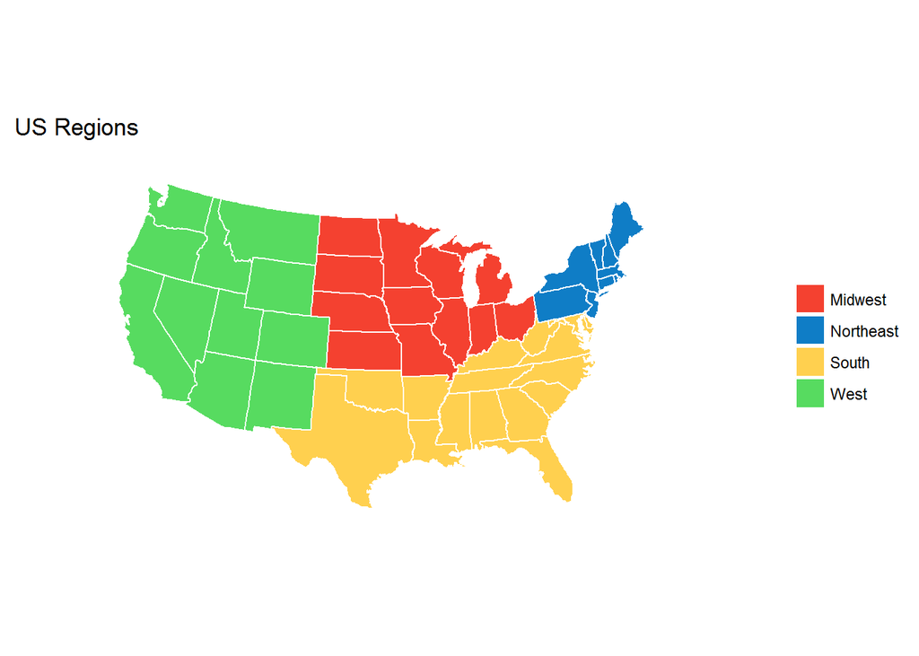

```r
# Color scheme for the regions map
RegColMap <- c("Midwest" = "#F44130", "Northeast" = "#0F7DC6", "South" = "#FFD04F", "West" = "#57DB60")

# Creating the region map
GGRegion <- USMap # Loading the map
GGRegion <- GGRegion + geom_map(data=Census2014, map=us, aes(fill=Region, map_id=State), color="#ffffff") # Setting the map to my specifications
GGRegion <- GGRegion + scale_fill_manual(values = RegColMap) + theme(panel.border=element_blank(), panel.background=element_blank(), axis.ticks=element_blank(), axis.text=element_blank()) + labs(x=NULL, y=NULL, fill=NULL, title="US Regions") + coord_map("albers", lat0=39, lat1=45) # Making the map beautiful
GGRegion
```

### 1.3.2 Divisions Map

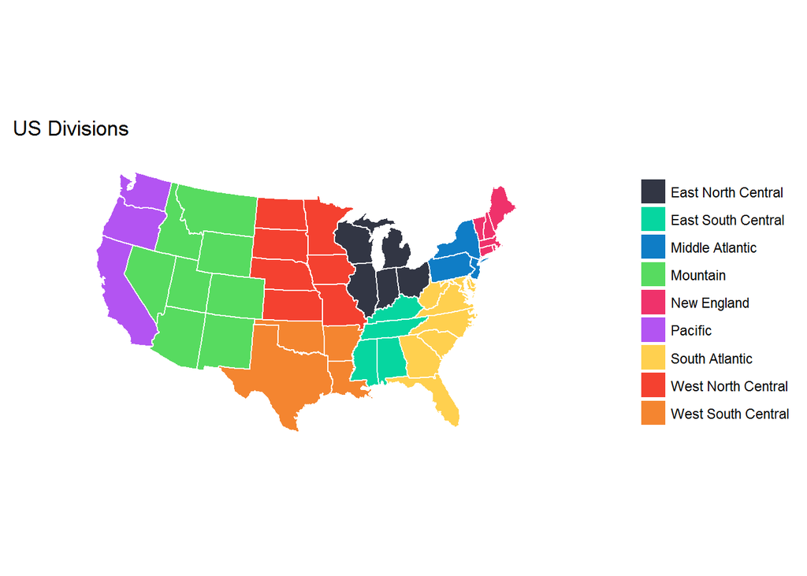

```r
# Color scheme for the divisions map (and later graphics)
DivColMap <- c("East North Central" = "#323644", "East South Central" = "#06d6a0", "Middle Atlantic" = "#0F7DC6", "Mountain" = "#57DB60", "New England" = "#EF326B", "Pacific" = "#B354F2", "South Atlantic" = "#FFD04F", "West North Central" = "#F44130", "West South Central" = "#F48530")

# Creating the division map
GGDivision <- USMap # Loading the map
GGDivision <- GGDivision + geom_map(data=Census2014, map=us, aes(fill=Division, map_id=State), color="#ffffff") # Setting the map to my specifications
GGDivision <- GGDivision + scale_fill_manual(values = DivColMap) + theme(panel.border=element_blank(), panel.background=element_blank(), axis.ticks=element_blank(), axis.text=element_blank()) + labs(x=NULL, y=NULL, fill=NULL, title="US Divisions") + coord_map("albers", lat0=39, lat1=45) # Making the map beautiful
GGDivision
```

## 1.4 Population and Birth, Death, and Natural Increase Rates (Maps)

I am interested to see how the population and birth, death, and natural increase rates look across the nation.

### 1.4.1 Population Map

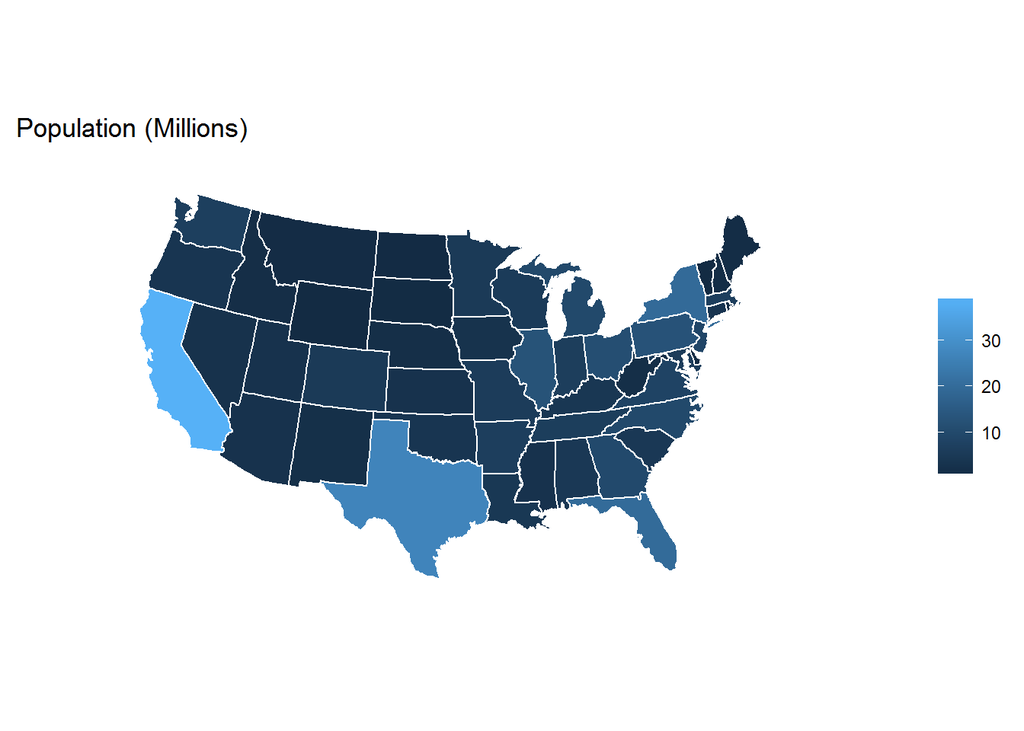

```r
# 2014 Population Estimate
Pop2014 <- USMap # Loading the map
Pop2014 <- Pop2014 + geom_map(data=Census2014, map=us, aes(fill=(Population/1000000), map_id=State), color="#ffffff") # Adding specifications
Pop2014 <- Pop2014 + theme(panel.border=element_blank(), panel.background=element_blank(), axis.ticks=element_blank(), axis.text=element_blank()) + labs(x=NULL, y=NULL, fill=NULL, title="Population (Millions)") + coord_map("albers", lat0=39, lat1=45) # Making the map beautiful
Pop2014
```

Unsurprisingly, the most populous states are California, Texas, Florida, and New York. This population map will help those not familiar with the population spread of the US.

### 1.4.2 Map of Birth Rate Map

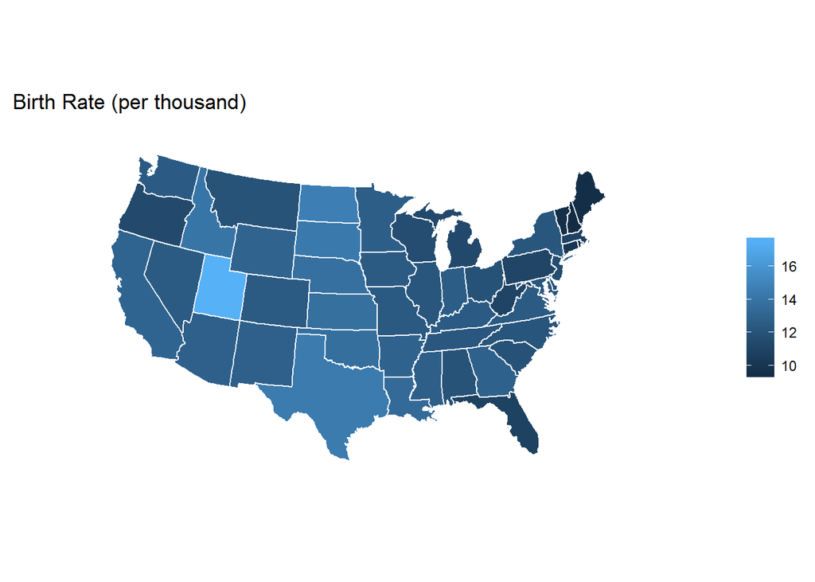

```r
# 2014 Birth Rate
Birth2014 <- USMap # Loading the map
Birth2014 <- Birth2014 + geom_map(data=Census2014, map=us, aes(fill=BirthRate, map_id=State), color="#ffffff") # Adding specifications
Birth2014 <- Birth2014 + theme(panel.border=element_blank(), panel.background=element_blank(), axis.ticks=element_blank(), axis.text=element_blank()) + labs(x=NULL, y=NULL, fill=NULL, title="Birth Rate (per thousand)") + coord_map("albers", lat0=39, lat1=45) # Making the map beautiful
Birth2014
```

It appears that Utah has a very high birth rate compared with the rest of the US.

### 1.4.3 Map of Death Rate

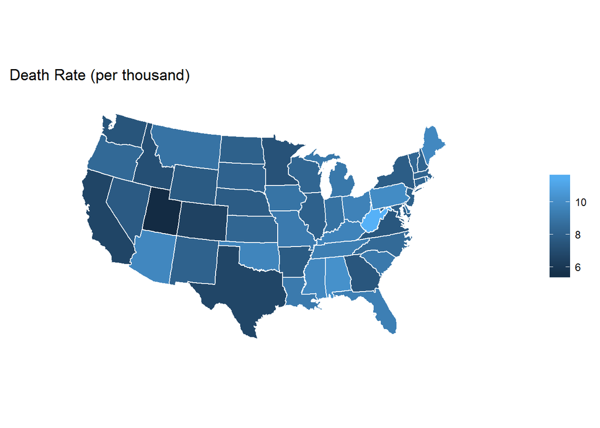

```r
# 2014 Death Rate
Death2014 <- USMap # Loading the map
Death2014 <- Death2014 + geom_map(data=Census2014, map=us, aes(fill=DeathRate, map_id=State), color="#ffffff") # Adding specifications
Death2014 <- Death2014 + theme(panel.border=element_blank(), panel.background=element_blank(), axis.ticks=element_blank(), axis.text=element_blank()) + labs(x=NULL, y=NULL, fill=NULL, title="Death Rate (per thousand)") + coord_map("albers", lat0=39, lat1=45) # Making the map beautiful
Death2014
```

West Virginia appears to have a large death rate - over 1% each year!

### 1.4.4 Map of Natural Population Increase

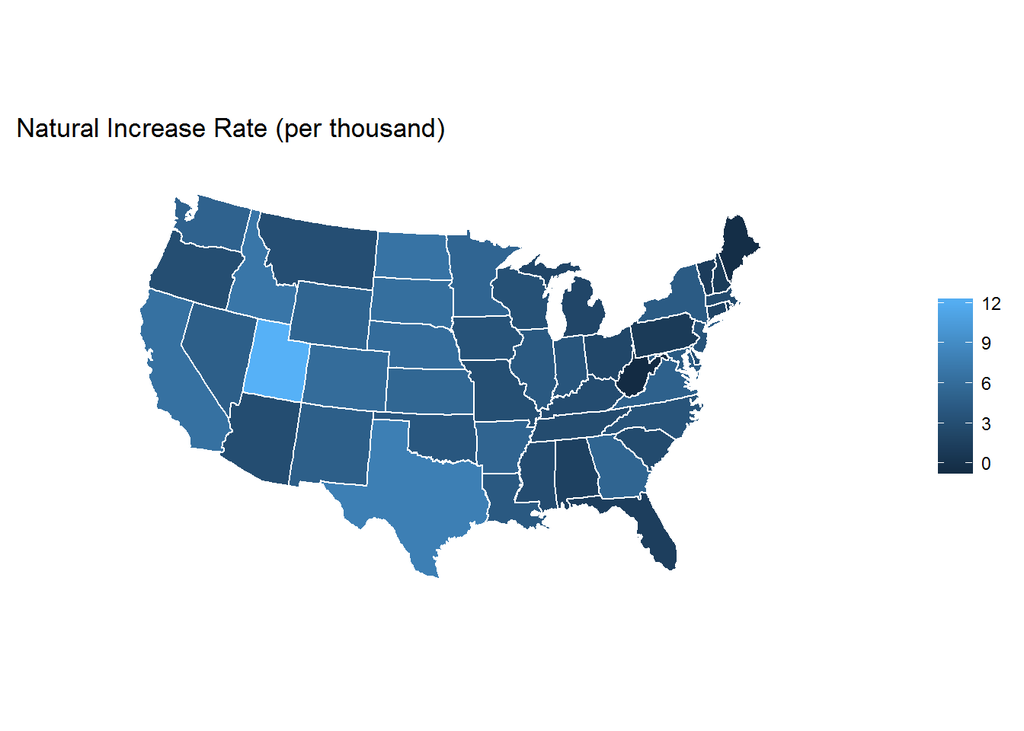

```r
# 2014 Natural Population Increase
NatInc2014 <- USMap # Loading the map
NatInc2014 <- NatInc2014 + geom_map(data=Census2014, map=us, aes(fill=NatIncRate, map_id=State), color="#ffffff") # Adding specifications
NatInc2014 <- NatInc2014 + theme(panel.border=element_blank(), panel.background=element_blank(), axis.ticks=element_blank(), axis.text=element_blank()) + labs(x=NULL, y=NULL, fill=NULL, title="Natural Increase Rate (per thousand)") + coord_map("albers", lat0=39, lat1=45) # Making the map beautiful
NatInc2014
```

As the natural increase is simply measured by taking the death rate from the birth rate, it is unsurprising that Utah’s is so large.

## 1.5 Migration Maps

For now, I will graph a few more population variables to get a sense of what the data show before conducting further analysis.

### 1.5.1 International Migration Map

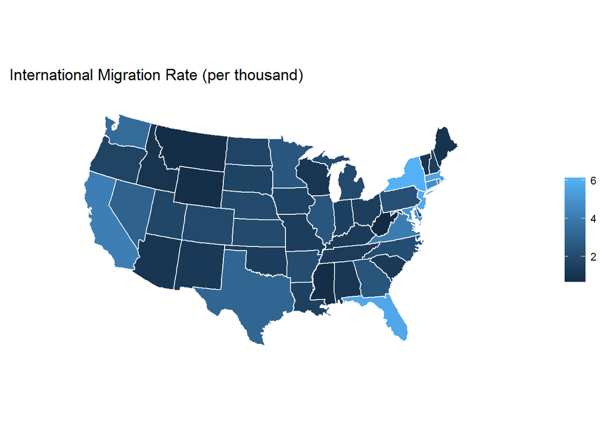

```r
# International Migration Rates
IntMig2014 <- USMap # Loading the map
IntMig2014 <- IntMig2014 + geom_map(data=Census2014, map=us, aes(fill=IntMigRate, map_id=State), color="#ffffff") # Adding specifications
IntMig2014 <- IntMig2014 + theme(panel.border=element_blank(), panel.background=element_blank(), axis.ticks=element_blank(), axis.text=element_blank()) + labs(x=NULL, y=NULL, fill=NULL, title="International Migration Rate (per thousand)") + coord_map("albers", lat0=39, lat1=45) # Making the map beautiful
IntMig2014
```

The rate of international migration is higher for populous coastal states, namely Florida, New York, Massachusetts, New Jersey, Virginia, California, etc.

### 1.5.2 Domestic Migration Map

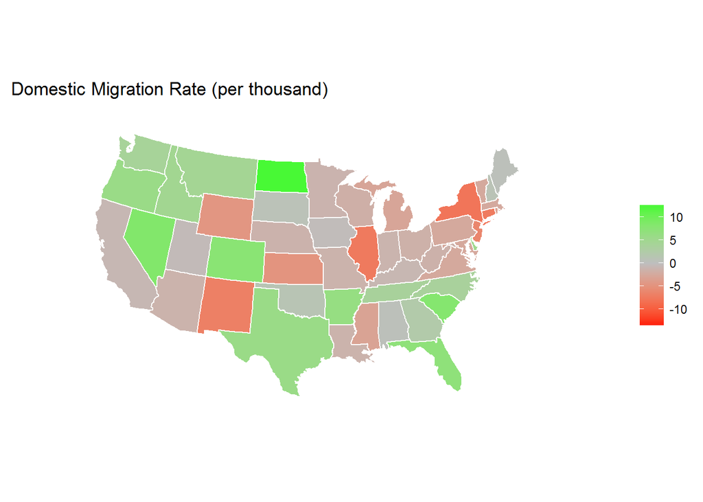

```r
# Domestic Migration Rates
DomMig2014 <- USMap # Loading the map
DomMig2014 <- DomMig2014 + geom_map(data=Census2014, map=us, aes(fill=DomMigRate, map_id=State), color="#ffffff") # Adding specifications
DomMig2014 <- DomMig2014 + theme(panel.border=element_blank(), panel.background=element_blank(), axis.ticks=element_blank(), axis.text=element_blank()) + labs(x=NULL, y=NULL, fill=NULL, title="Domestic Migration Rate (per thousand)") + coord_map("albers", lat0=39, lat1=45) + scale_fill_gradient2(low="red", mid="grey", high="green") # Making the map beautiful
DomMig2014
```

The rate of domestic migration definitely favors the south east and north west US more.

### 1.5.3 Net Migration Map

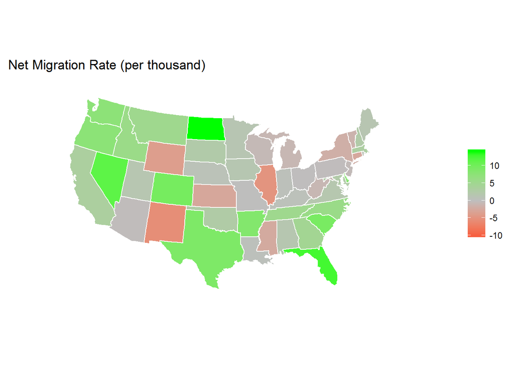

```r
# Net Migration Rates
NetMig2014 <- USMap # Loading the map
NetMig2014 <- NetMig2014 + geom_map(data=Census2014, map=us, aes(fill=NetMigRate, map_id=State), color="#ffffff") # Adding specifications
NetMig2014 <- NetMig2014 + theme(panel.border=element_blank(), panel.background=element_blank(), axis.ticks=element_blank(), axis.text=element_blank()) + labs(x=NULL, y=NULL, fill=NULL, title="Net Migration Rate (per thousand)") + coord_map("albers", lat0=39, lat1=45) + scale_fill_gradient2(low="red", mid="grey", high="green") # Making the map beautiful
NetMig2014
```

## 1.6 Maps of Population Change

Before I look past the maps, I am interested in seeing how the population changed from 2013 to 2014. I think this will give me a much better sense of the data.

```r
# Creating the variables to map
Census2014$PopChangeRate2014 <- Census2014$Population / StateData$POPESTIMATE2013
Census2014$PopChange2014 <- Census2014$Population - StateData$POPESTIMATE2013
```

### 1.6.1 Rate of Population Change (Map)

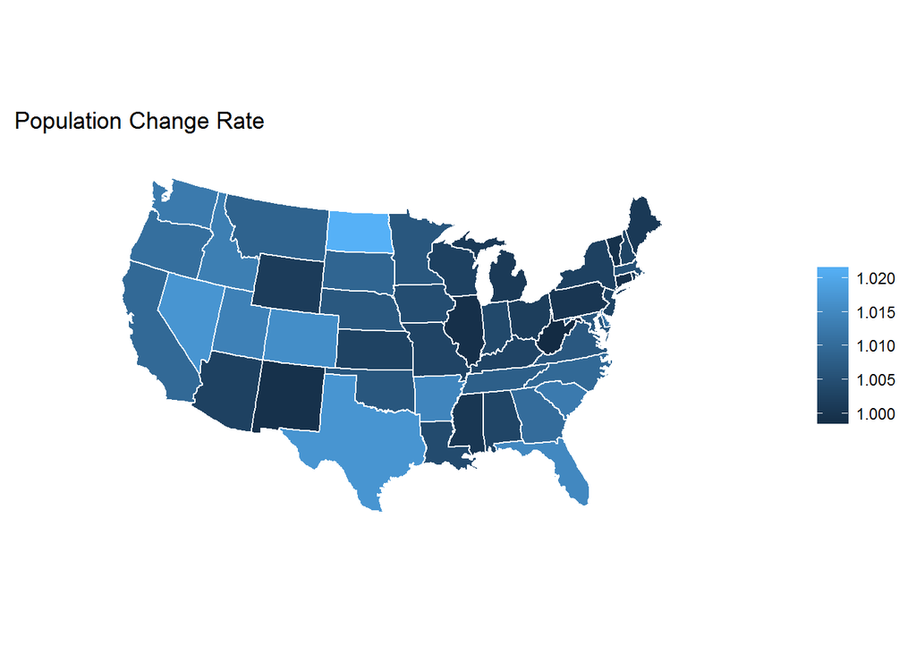

```r
PopChangeRate2014 <- USMap # Loading the map
PopChangeRate2014 <- PopChangeRate2014 + geom_map(data=Census2014, map=us, aes(fill=PopChangeRate2014, map_id=State), color="#ffffff") # Adding specifications
PopChangeRate2014 <- PopChangeRate2014 + theme(panel.border=element_blank(), panel.background=element_blank(), axis.ticks=element_blank(), axis.text=element_blank()) + labs(x=NULL, y=NULL, fill=NULL, title="Population Change Rate") + coord_map("albers", lat0=39, lat1=45) # Making the map beautiful
PopChangeRate2014
```

### 1.6.2 Numbers of Population Change (Map)

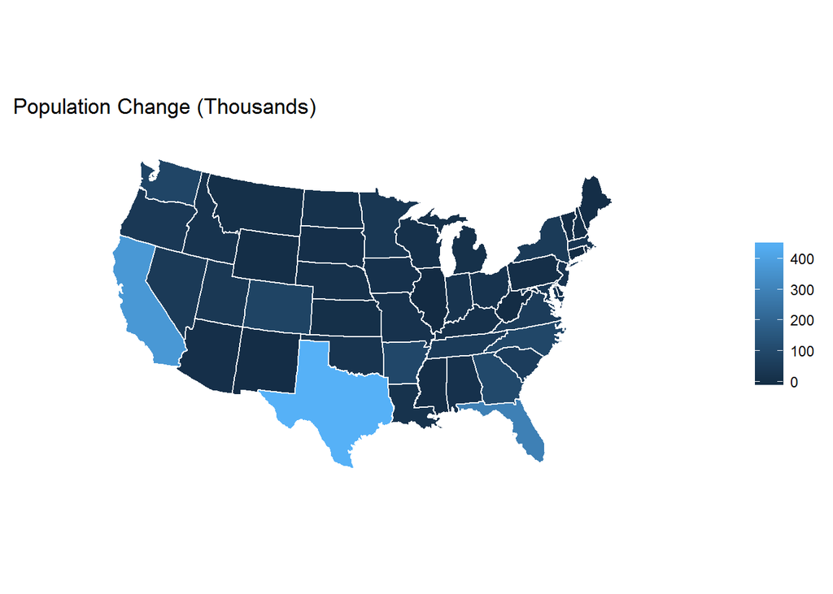

```r
PopChange2014 <- USMap # Loading the map
PopChange2014 <- PopChange2014 + geom_map(data=Census2014, map=us, aes(fill=(PopChange2014/1000), map_id=State), color="#ffffff") # Adding specifications
PopChange2014 <- PopChange2014 + theme(panel.border=element_blank(), panel.background=element_blank(), axis.ticks=element_blank(), axis.text=element_blank()) + labs(x=NULL, y=NULL, fill=NULL, title="Population Change (Thousands)") + coord_map("albers", lat0=39, lat1=45) # Making the map beautiful
PopChange2014
```

Unsurprisingly, the states that gained the most population were California, Texas, and Florida.

# 2 Analyses

## 2.1 Big Picture

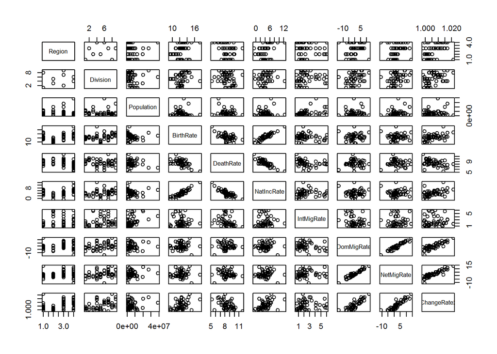

```r
# Looking at all the variables to provide context and identify trends
pairs(subset(Census2014, select=c("Region", "Division", "Population", "BirthRate", "DeathRate", "NatIncRate", "IntMigRate", "DomMigRate", "NetMigRate", "PopChangeRate2014")))
```

Though this graphic has a lot of information (and may be difficult to see based on the size of your screen), it allows us to see 2 incredibly valuable pieces of information very easily and quickly:  
* The birth, death, and natural increase rates seem to be highly correlated. Additionally, the domestic and net migration rates, along with the population change rages, are highly correlated.  
* We are able to see the trends among the Regions and Divisions (think of the scatter plots for Region and Division as box plots).

## 2.2 Population, Birth, Death, and Natural Increase

To begin the analysis, I will start with just looking at the relationship among a cluster of similar variables - population and rates of birth, death, and natural increase.

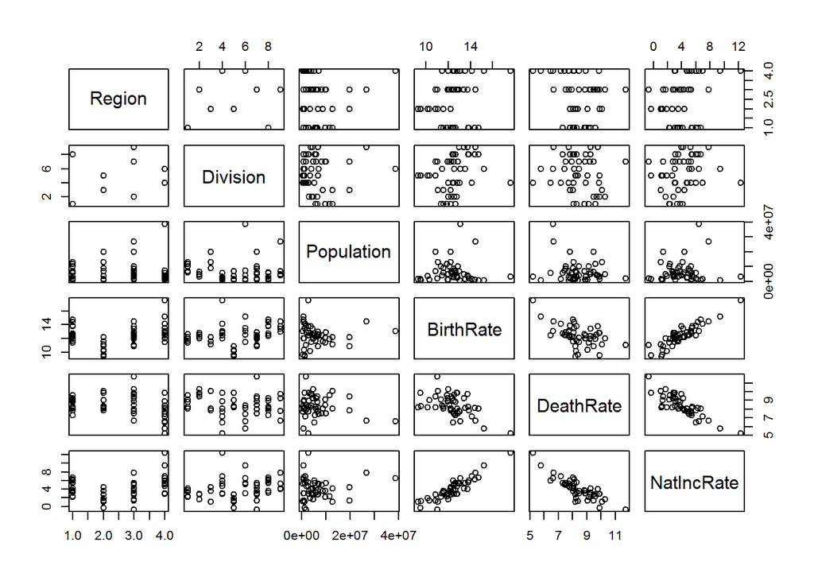

```r
# Pairs of the population and birth, death, and natural increase rates
pairs(subset(Census2014, select=c("Region", "Division", "Population", "BirthRate", "DeathRate", "NatIncRate")))
```

As noticed earlier, it appears there is a strong relationship between Birth Rate, Death Rate, and Natural Increase Rate. Of course, the strong correlations with Natural Increase Rate are because it is calculated by subtracting the death rate from the birth rate.

I am interested to see how these rates differ by division.

```r
# Birth, Death, and Natural Increase Rates by Division

group_by(Census2014, Division) %>%
  summarise(BirthRate = round(mean(BirthRate), 2), DeathRate = round(mean(DeathRate), 2), NatIncRate = round(mean(NatIncRate), 2))
```

```
## # A tibble: 9 × 4
##             Division BirthRate DeathRate NatIncRate
##               <fctr>     <dbl>     <dbl>      <dbl>
## 1 East North Central     11.95      8.78       3.17
## 2 East South Central     12.39      9.82       2.57
## 3    Middle Atlantic     11.64      8.64       3.00
## 4           Mountain     13.43      7.65       5.79
## 5        New England      9.97      8.64       1.32
## 6            Pacific     13.17      7.28       5.89
## 7     South Atlantic     11.95      8.85       3.10
## 8 West North Central     13.47      8.25       5.22
## 9 West South Central     13.66      8.35       5.31
```

New England has the lowest birth rate by far. Similarly, the East South Central has quite a high death rate compared with other divisions.

As the maps above show that particular states stand out, I am interested to see which states are affecting these trends…

### 2.2.1 Birth Rates (Low)

```r
# States with 10 lowest birth rates by division

# Creating table of states with 10 lowest birth rates
BirthRateLow <- select(Census2014, State, Division, BirthRate) %>%
  filter(BirthRate <= sort(BirthRate)[10]) %>%
  mutate(BirthRate = round(BirthRate, 2))

# Table of states with 10 lowest birth rates
BirthRateLow %>%
  arrange(desc(BirthRate))
```

```
##            State           Division BirthRate
## 1       michigan East North Central     11.38
## 2   pennsylvania    Middle Atlantic     11.11
## 3  west virginia     South Atlantic     11.05
## 4  massachusetts        New England     10.89
## 5        florida     South Atlantic     10.87
## 6   rhode island        New England     10.36
## 7    connecticut        New England     10.14
## 8        vermont        New England      9.58
## 9          maine        New England      9.52
## 10 new hampshire        New England      9.31
```

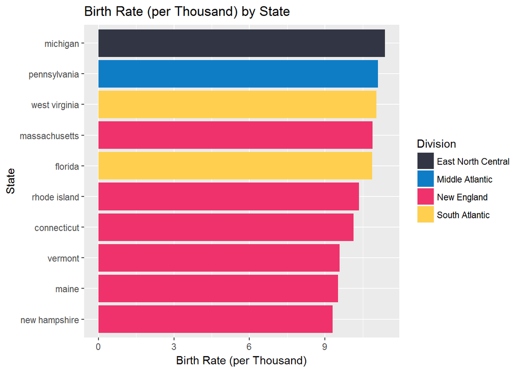

```r
# Graph of states with 10 lowest birth rates
BirthRateLowBar <- ggplot(BirthRateLow, aes(reorder(State, BirthRate), BirthRate, fill=Division)) # Creating the basic graph
BirthRateLowBar <- BirthRateLowBar + geom_col() + coord_flip() + labs(y="Birth Rate (per Thousand)", x="State", title="Birth Rate (per Thousand) by State")  + scale_fill_manual(values=DivColMap)
BirthRateLowBar
```

- No wonder New England has such a low average birth rate - all 6 states are in the lowest 10 in birth rate!
- The other 4 states within the lowest 10 birth rates are more scattered, but still in the Eastern part of the US (Michigan is the farthest west). I am interested to see how migration rates affect the overall population change in these states, as they are not [re]producing many people themselves.

### 2.2.2 Birth Rates (High)

```r
# States with 10 highest birth rates by division

# Creating table of states with 10 highest birth rates
BirthRateHigh <- select(Census2014, State, Division, BirthRate) %>%
  filter(BirthRate >= sort(BirthRate)[41]) %>%
  mutate(BirthRate = round(BirthRate, 2))

# Table of states with 10 highest birth rates
BirthRateHigh %>%
  arrange(desc(BirthRate))
```

```
##           State           Division BirthRate
## 1          utah           Mountain     17.60
## 2        alaska            Pacific     15.23
## 3  north dakota West North Central     14.73
## 4         texas West South Central     14.47
## 5  south dakota West North Central     14.38
## 6         idaho           Mountain     14.13
## 7      nebraska West North Central     13.84
## 8        kansas West North Central     13.79
## 9      oklahoma West South Central     13.73
## 10       hawaii            Pacific     13.52
```

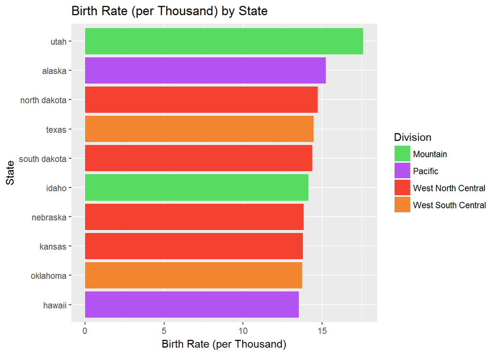

```r
# Graph of states with 10 highest birth rates
BirthRateHighBar <- ggplot(BirthRateHigh, aes(reorder(State, BirthRate), BirthRate, fill=Division)) # Creating the basic graph
BirthRateHighBar <- BirthRateHighBar + geom_col() + coord_flip() + labs(y="Birth Rate (per Thousand)", x="State", title="Birth Rate (per Thousand) by State")  + scale_fill_manual(values=DivColMap)
BirthRateHighBar
```

- Following the trends with the lowest birth rates, the states with the highest birth rates are in the west. Notably, 4 out of 7 states in the West North Central division are within the top 10 birth rates.
- I am most interested as to why Utah’s birth rate is so high.
  - After some quick research, it appears that a large of this may be because of the number of people in Utah who belong to The Church of Jesus Christ of Latter-day Saints, a religious group that highly values family. Here is an article that looks more into this, though not as scientifically as I would prefer: http://www.deseretnews.com/article/700251966/Utahs-birthrate-highest-in-US.html
- I am also interested in why both Alaska *and* Hawai’i are within the top 10. There may not be a trend here, but it is interesting that both the states not in the continental US are within this list. (Hawai’i just barely made it, and Alaska is second after Utah, so I may be trying to find a trend where there is not one.)

### 2.2.3 Death Rates (Low)

```r
# States with 10 lowest death rates by division

# Creating table of states with 10 lowest death rates
DeathRateLow <- select(Census2014, State, Division, DeathRate) %>%
  filter(DeathRate <= sort(DeathRate)[10]) %>%
  mutate(DeathRate = round(DeathRate,2))

# Table of states with 10 lowest death rates
DeathRateLow %>%
  arrange(desc(DeathRate))
```

```
##         State           Division DeathRate
## 1    virginia     South Atlantic      7.53
## 2     georgia     South Atlantic      7.52
## 3  washington            Pacific      7.45
## 4   minnesota West North Central      7.30
## 5       idaho           Mountain      7.16
## 6       texas West South Central      6.67
## 7  california            Pacific      6.62
## 8    colorado           Mountain      6.46
## 9      alaska            Pacific      5.76
## 10       utah           Mountain      5.24
```

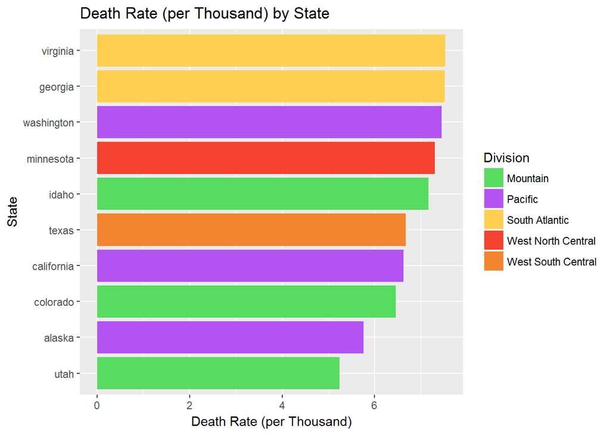

```r
# Graph of states with 10 lowest death rates
DeathRateLowBar <- ggplot(DeathRateLow, aes(reorder(State, DeathRate), DeathRate, fill=Division)) # Creating the basic graph
DeathRateLowBar <- DeathRateLowBar + geom_col() + coord_flip() + labs(y="Death Rate (per Thousand)", x="State", title="Death Rate (per Thousand) by State")  + scale_fill_manual(values=DivColMap)
DeathRateLowBar
```

- Unsurprisingly, 4 out of the 10 states with the lowest death rates are also states within the top 10 of highest birth rates (Utah, Idaho, Texas, and Alaska). Additionally, the two lowest are the states with the 2 highest birth rates (Utah and Alaska).
- Though most of these states are in the west, 2 states (Georgia and Virginia) are along the Atlantic.

### 2.2.4 Death Rates (High)

```r
# States with 10 highest death rates by division

# Creating table of states with 10 highest death rates
DeathRateHigh <- select(Census2014, State, Division, DeathRate) %>%
  filter(DeathRate >= sort(DeathRate)[41]) %>%
  mutate(DeathRate = round(DeathRate, 2))

# Table of states with 10 highest death rates
DeathRateHigh %>%
  arrange(desc(DeathRate))
```

```
##            State           Division DeathRate
## 1  west virginia     South Atlantic     11.74
## 2        alabama East South Central     10.28
## 3   pennsylvania    Middle Atlantic     10.06
## 4          maine        New England      9.88
## 5    mississippi East South Central      9.88
## 6        arizona           Mountain      9.87
## 7       oklahoma West South Central      9.75
## 8       kentucky East South Central      9.68
## 9           ohio East North Central      9.60
## 10       florida     South Atlantic      9.48
```

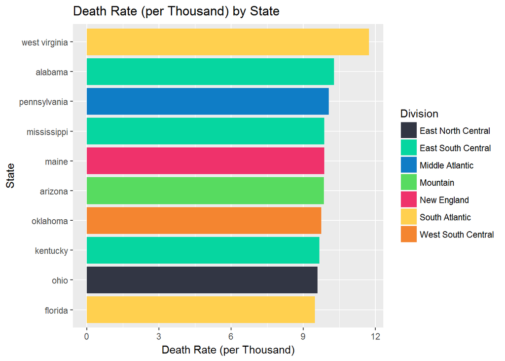

```r
# Graph of states with 10 highest death rates
DeathRateHighBar <- ggplot(DeathRateHigh, aes(reorder(State, DeathRate), DeathRate, fill=Division)) # Creating the basic graph
DeathRateHighBar <- DeathRateHighBar + geom_col() + coord_flip() + labs(y="Death Rate (per Thousand)", x="State", title="Death Rate (per Thousand) by State")  + scale_fill_manual(values=DivColMap)
DeathRateHighBar
```

- The first thing to notice is West Virginia’s incredibly high death rate (comparatively). It appears that this could be partially due to the opioid epedemic ravaging the state in the past few years (https://www.washingtonpost.com/news/wonk/wp/2017/03/07/drugs-are-killing-so-many-people-in-west-virginia-the-state-cant-keep-up-with-the-funerals/?utm_term=.f460199e34d5).
- Three out of the 4 states in the East South Central division are within the 10 highest death rates, which is rather alarming.
- Similar to low birth rates, *most of the states (all but Oklahoma and Arizona) are in the east.*

### 2.2.5 Nat. Inc. Rates (Low)

```r
# States with 10 lowest natural increase rates by state and division

# Creating table of states with 10 lowest natural increase rates
NatIncRateLow <- select(Census2014, State, Division, NatIncRate) %>%
  filter(NatIncRate <= sort(NatIncRate)[10]) %>%
  mutate(NatIncRate = round(NatIncRate, 2))

# Table of states with 10 lowest natural increase rates
NatIncRateLow %>%
  arrange(desc(NatIncRate))
```

```
##            State           Division NatIncRate
## 1       michigan East North Central       2.26
## 2    connecticut        New England       1.92
## 3        alabama East South Central       1.71
## 4        florida     South Atlantic       1.39
## 5   rhode island        New England       1.30
## 6        vermont        New England       1.23
## 7  new hampshire        New England       1.14
## 8   pennsylvania    Middle Atlantic       1.05
## 9          maine        New England      -0.36
## 10 west virginia     South Atlantic      -0.69
```

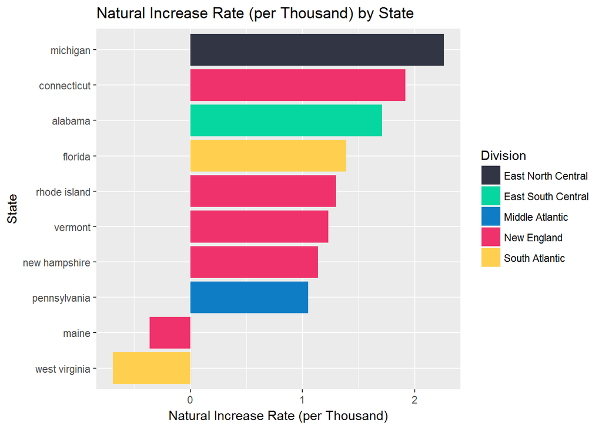

```r
# Graph of states with 10 lowest natural increase rates
NatIncRateLowBar <- ggplot(NatIncRateLow, aes(reorder(State, NatIncRate), NatIncRate, fill=Division)) # Creating the basic graph
NatIncRateLowBar <- NatIncRateLowBar + geom_col() + coord_flip() + labs(y="Natural Increase Rate (per Thousand)", x="State", title="Natural Increase Rate (per Thousand) by State")  + scale_fill_manual(values=DivColMap)
NatIncRateLowBar
```

- Most notably, *2 states have natural increase rates below 0* (West Virginia and Maine)! It appears that Maine is just getting older and its people are not having as many babies (http://www.pressherald.com/2013/03/14/census-maine-counties-losing-population/). With West Virginia’s lower-than-average birth rate and incredibly high death rate, this number makes sense.
- As expected, half of the states in the bottom 10 natural increase rates are from New England (5/6 of the New England states are within the bottom 10).
- The bottom 10 are comprised of states in the east, following the earlier trends.

### 2.2.6 Nat. Inc. Rates (High)

```r
# States with 10 highest natural increase rates by state and division

# Creating table of states with 10 lowest natural increase rates
NatIncRateHigh <- select(Census2014, State, Division, NatIncRate) %>%
  filter(NatIncRate >= sort(NatIncRate)[41]) %>%
  mutate(NatIncRate = round(NatIncRate, 2))

# Table of states with 10 highest natural increase rates
NatIncRateHigh %>%
  arrange(desc(NatIncRate)) # States with 10 highest rates of natural increase
```

```
##           State           Division NatIncRate
## 1          utah           Mountain      12.37
## 2        alaska            Pacific       9.47
## 3         texas West South Central       7.80
## 4         idaho           Mountain       6.97
## 5  north dakota West North Central       6.70
## 6    california            Pacific       6.48
## 7  south dakota West North Central       6.27
## 8      nebraska West North Central       6.03
## 9      colorado           Mountain       6.01
## 10       kansas West North Central       5.51
```

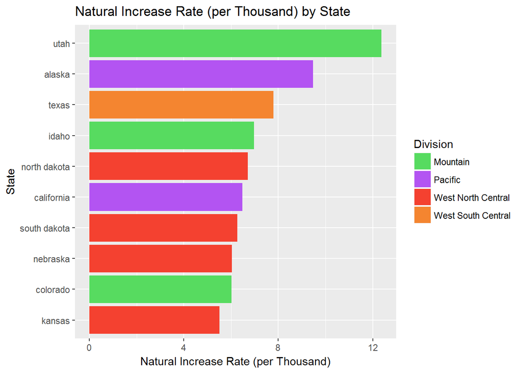

```r
# Graph of states with 10 lowest natural increase rates
NatIncRateHighBar <- ggplot(NatIncRateHigh, aes(reorder(State, NatIncRate), NatIncRate, fill=Division)) # Creating the basic graph
NatIncRateHighBar <- NatIncRateHighBar + geom_col() + coord_flip() + labs(y="Natural Increase Rate (per Thousand)", x="State", title="Natural Increase Rate (per Thousand) by State")  + scale_fill_manual(values=DivColMap)
NatIncRateHighBar
```

- Unsurprisingly, Utah is number one in terms of rate of natural increase. as a result of their high birth rate and low death rate.
- Four out of 7 states in the West North Central are represented in the top 10, and 3 states in the mountain division.

## 2.3 Migration Rates by Division

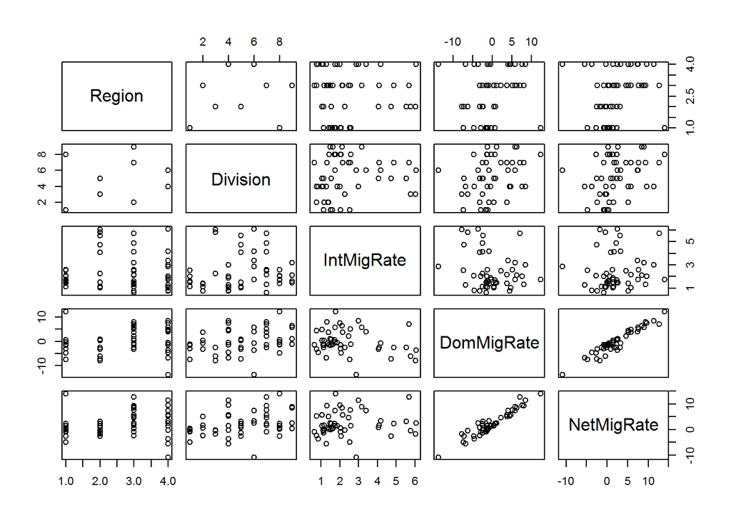

```r
pairs(subset(Census2014, select=c("Region", "Division", "IntMigRate", "DomMigRate", "NetMigRate")))
```

- Right away, I notice that domestic migration and net migration are heavily correlated, indicating the domestic migration has a larger effect on net migration than international migration.
- It also looks like there are some trends within the regions and divisions, as some regions and divisions are more clustered and others are more spread out.

I am interested to see how the rates are broken down by division.

### 2.3.1 Int. Migration Rate

```r
# International Migration Rates by Division

# Table of international migration rates by division
IntMigDivRateTbl <- group_by(Census2014, Division) %>%
  summarise(IntMigRate = round(mean(IntMigRate), 2)) %>%
  arrange(desc(IntMigRate))
IntMigDivRateTbl
```

```
## # A tibble: 9 × 2
##             Division IntMigRate
##               <fctr>      <dbl>
## 1    Middle Atlantic       4.69
## 2            Pacific       3.65
## 3        New England       3.01
## 4     South Atlantic       2.97
## 5 West South Central       2.10
## 6 West North Central       1.90
## 7 East North Central       1.76
## 8           Mountain       1.49
## 9 East South Central       1.17
```

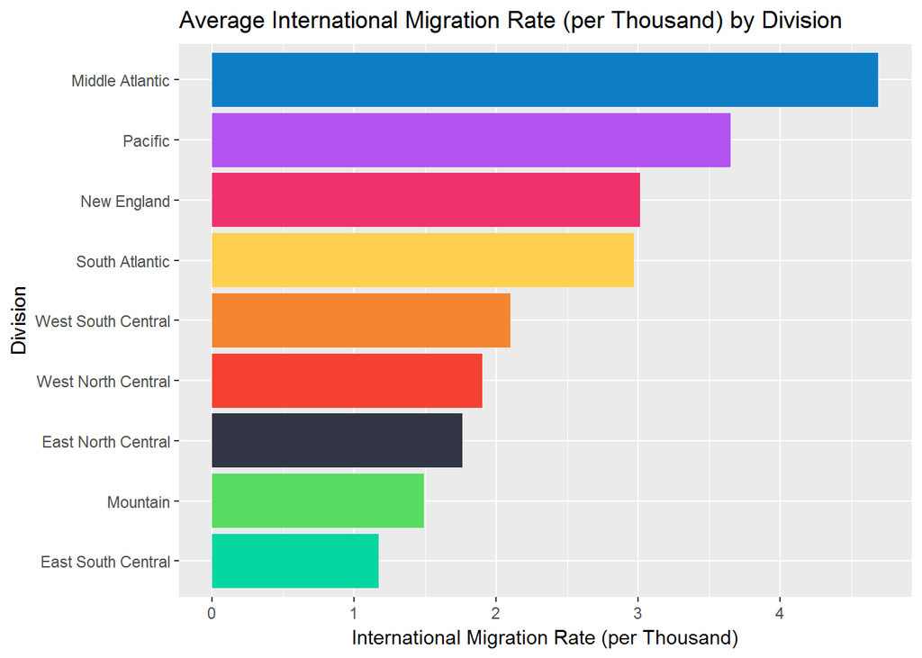

```r
# Graph of international migration rates by division
IntMigDivRateBar <- ggplot(IntMigDivRateTbl, aes(reorder(Division, IntMigRate), IntMigRate, fill=Division)) # Creating basic graphic
IntMigDivRateBar <- IntMigDivRateBar + geom_col() + coord_flip() + labs(y="International Migration Rate (per Thousand)", x="Division", title="Average International Migration Rate (per Thousand) by Division")  + scale_fill_manual(values=DivColMap) + theme(legend.position="None")
IntMigDivRateBar
```

- Given that the average international migration rate is above 0 for every division, I was a bit surprised to find that the international migration rate *also includes people moving outside of the United States*. (https://www.census.gov/population/www/documentation/twps0051/twps0051.html).
- I am not surprised to see that the International migration rate for the Middle Atlantic is so high as the maps above hinted at this trend.

### 2.3.2 Dom. Migration Rate

```r
# Domestic Migration Rates by Division

# Creating table of domestic migration rates by division
DomMigDivRateTbl <- group_by(Census2014, Division) %>%
  summarise(DomMigRate = round(mean(DomMigRate), 2)) %>%
  arrange(desc(DomMigRate))
DomMigDivRateTbl
```

```
## # A tibble: 9 × 2
##             Division DomMigRate
##               <fctr>      <dbl>
## 1 West South Central       2.97
## 2     South Atlantic       2.44
## 3           Mountain       1.51
## 4 West North Central       0.57
## 5 East South Central       0.05
## 6            Pacific      -1.70
## 7        New England      -2.36
## 8 East North Central      -2.95
## 9    Middle Atlantic      -5.49
```

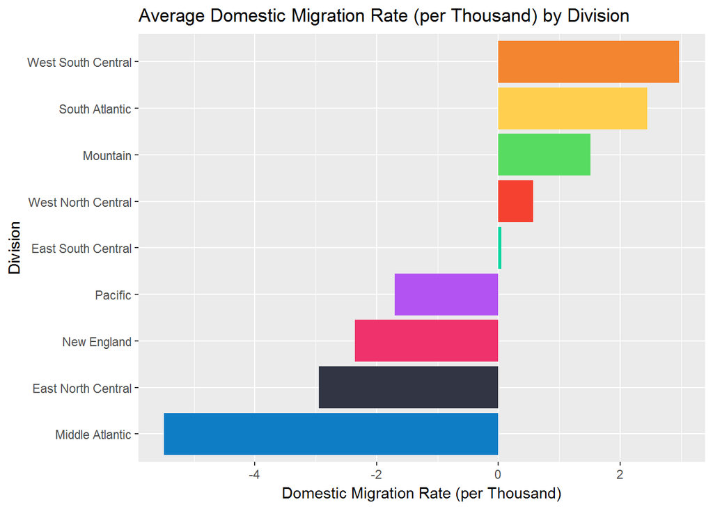

```r
# Creating graph of domestic migration rates by division
DomMigDivRateBar <- ggplot(DomMigDivRateTbl, aes(reorder(Division, DomMigRate), DomMigRate, fill=Division)) # Creating the basic graph
DomMigDivRateBar <- DomMigDivRateBar + geom_col() + coord_flip() + labs(y="Domestic Migration Rate (per Thousand)", x="Division", title="Average Domestic Migration Rate (per Thousand) by Division")  + scale_fill_manual(values=DivColMap) + theme(legend.position="None")
DomMigDivRateBar
```

- Again, following the trends identified in the maps above, I am unsurprised that the domestic migration rate for the Middle Atlantic is so low.
- That being said, I *am* surprised to see that other divisions are losing so many people through domestic migration.

### 2.3.3 Net Migration Rate

```r
# Net Migration Rates by Division

# Creating Table of Net Migration Rates by Division
NetMigDivRateTbl <- group_by(Census2014, Division) %>%
  summarize(NetMigRate= round(mean(NetMigRate), 2))

NetMigDivRateTbl %>%
  arrange(desc(NetMigRate))
```

```
## # A tibble: 9 × 2
##             Division NetMigRate
##               <fctr>      <dbl>
## 1     South Atlantic       5.42
## 2 West South Central       5.07
## 3           Mountain       3.00
## 4 West North Central       2.47
## 5            Pacific       1.95
## 6 East South Central       1.21
## 7        New England       0.65
## 8    Middle Atlantic      -0.80
## 9 East North Central      -1.19
```

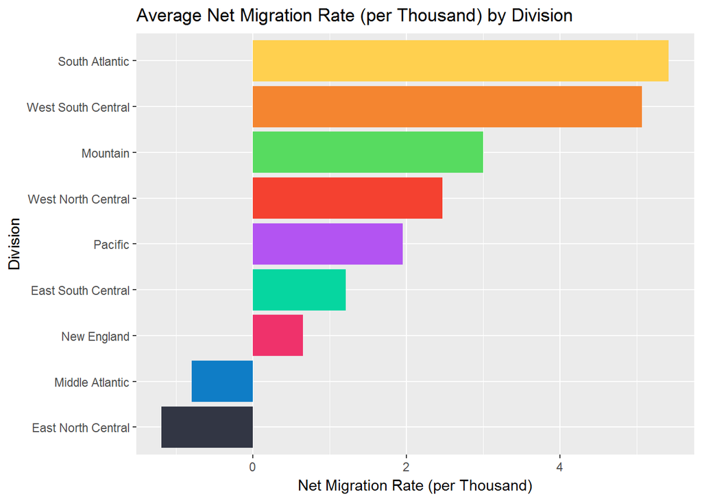

```r
# Creating Graph of Net Migration Rates by Division
NetMigDivRateBar <- ggplot(NetMigDivRateTbl, aes(reorder(Division, NetMigRate), NetMigRate, fill=Division)) # Creating the basic graph
NetMigDivRateBar <- NetMigDivRateBar + geom_col() + coord_flip() + labs(y="Net Migration Rate (per Thousand)", x="Division", title="Average Net Migration Rate (per Thousand) by Division")  + scale_fill_manual(values=DivColMap) + theme(legend.position="None")
NetMigDivRateBar
```

- Notably, the South Atlantic and West South Central divisions have a comparatively large net migration rate while the East North Central and Middle Atlantic divisions have a net migration rate lower than 0.

## 2.4 Migration Rates (Highest and Lowest)

It looks like there are some large differences among the divisions. I am interested to see which states are affecting the trends.

### 2.4.1 Int. Migration (Low)

```r
# States with 10 lowest international migration rates by division and state

# Creating table of states with 10 lowest international migration rates
IntMigRateLow <- select(Census2014, State, Division, IntMigRate) %>%
  filter(IntMigRate <= sort(IntMigRate)[10]) %>%
  mutate(IntMigRate = round(IntMigRate, 2))

# Table of states with 10 lowest international migration rates
IntMigRateLow %>%
  arrange(desc(IntMigRate))
```

```
##            State           Division IntMigRate
## 1        alabama East South Central       1.16
## 2        vermont        New England       1.15
## 3      wisconsin East North Central       1.14
## 4        arizona           Mountain       1.09
## 5          idaho           Mountain       1.04
## 6          maine        New England       1.04
## 7        wyoming           Mountain       0.83
## 8    mississippi East South Central       0.75
## 9        montana           Mountain       0.75
## 10 west virginia     South Atlantic       0.63
```

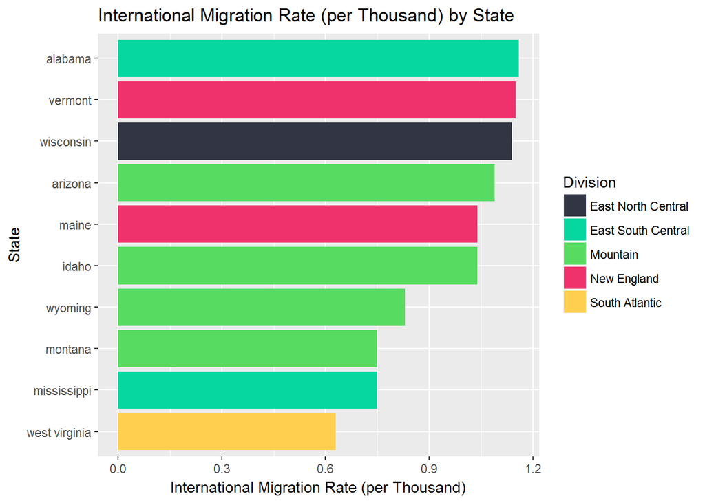

```r
# Graph of states with 10 lowest international migration rates
IntMigRateLowBar <- ggplot(IntMigRateLow, aes(reorder(State, IntMigRate), IntMigRate, fill=Division)) # Creating the basic graph
IntMigRateLowBar <- IntMigRateLowBar + geom_col() + coord_flip() + labs(y="International Migration Rate (per Thousand)", x="State", title="International Migration Rate (per Thousand) by State")  + scale_fill_manual(values=DivColMap)
IntMigRateLowBar
```

- It appears that there is no outlier within the bottom 10 international migration rates, but there are some trends within the divisions that are represented.
- Half of the states in the Mountain and East South Central divisions are in the lowest 10.

### 2.4.2 Int. Migration (High)

```r
# States with 10 highest international migration rates by division and state

# Creating table of states with 10 highest international migration rates
IntMigRateHigh <- select(Census2014, State, Division, IntMigRate) %>%
  filter(IntMigRate >= sort(IntMigRate)[41]) %>%
  mutate(IntMigRate = round(IntMigRate, 2))

# Table of states with 10 highest international migration rates
IntMigRateHigh %>%
  arrange(desc(IntMigRate))
```

```
##            State        Division IntMigRate
## 1         hawaii         Pacific       6.07
## 2       new york Middle Atlantic       6.02
## 3     new jersey Middle Atlantic       5.78
## 4        florida  South Atlantic       5.69
## 5  massachusetts     New England       5.54
## 6       maryland  South Atlantic       4.86
## 7    connecticut     New England       4.73
## 8     california         Pacific       4.18
## 9       virginia  South Atlantic       4.10
## 10  rhode island     New England       4.07
```

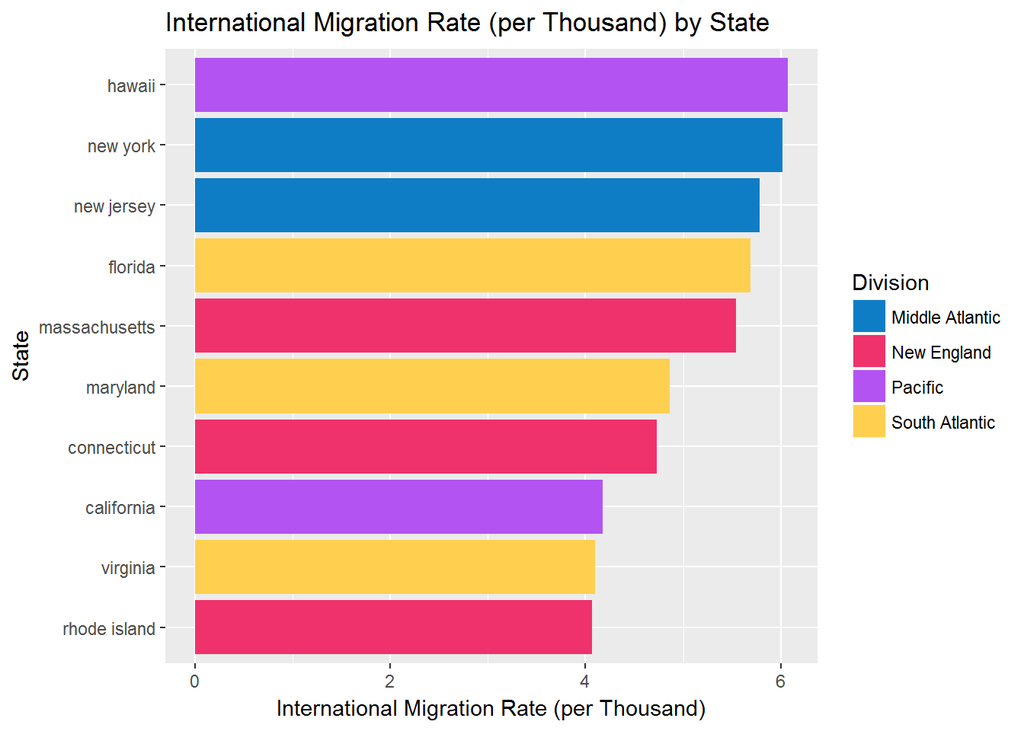

```r
# Graph of states with 10 highest international migration rates
IntMigRateHighBar <- ggplot(IntMigRateHigh, aes(reorder(State, IntMigRate), IntMigRate, fill=Division)) # Creating the basic graph
IntMigRateHighBar <- IntMigRateHighBar + geom_col() + coord_flip() + labs(y="International Migration Rate (per Thousand)", x="State", title="International Migration Rate (per Thousand) by State")  + scale_fill_manual(values=DivColMap)
IntMigRateHighBar
```

- Naturally, there is a very strong trend with the highest 10 international migration rates: *all the states border an ocean*! Thus, all the states are either on the east or west coasts
- The results are unsurprising otherwise.

### 2.4.3 Dom. Migration (Low)

```r
# Lowest domestic migration rates by state and division

# Creating table of states with the 10 lowest domestic migration rates
DomMigRateLow <- select(Census2014, State, Division, DomMigRate) %>%
  filter(DomMigRate <= sort(DomMigRate)[10]) %>%
  mutate(DomMigRate = round(DomMigRate, 2))

# Table of states with the 10 lowest domestic migration rates
DomMigRateLow %>%
  arrange(desc(DomMigRate))
```

```
##           State           Division DomMigRate
## 1  rhode island        New England      -3.21
## 2        hawaii            Pacific      -3.64
## 3       wyoming           Mountain      -4.58
## 4        kansas West North Central      -4.76
## 5    new jersey    Middle Atlantic      -6.22
## 6    new mexico           Mountain      -6.78
## 7   connecticut        New England      -7.29
## 8      illinois East North Central      -7.37
## 9      new york    Middle Atlantic      -7.80
## 10       alaska            Pacific     -13.75
```

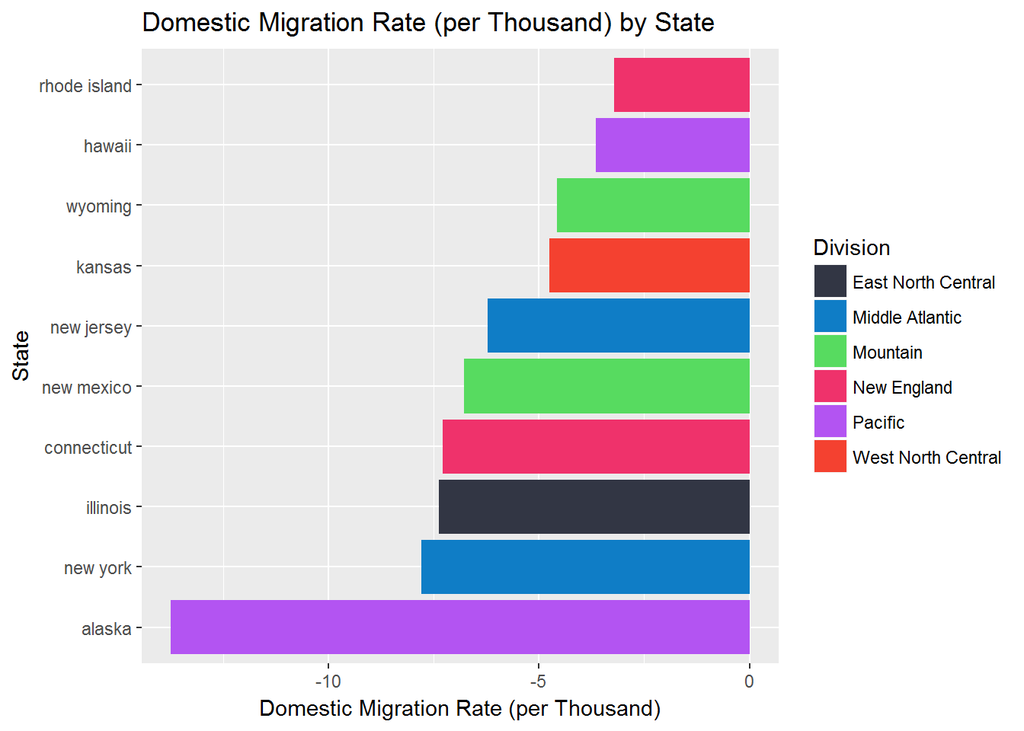

```r
# Graph of states with the 10 lowest domestic migration rates
DomMigRateLowBar <- ggplot(DomMigRateLow, aes(reorder(State, DomMigRate), DomMigRate, fill=Division)) # Creating the basic plot
DomMigRateLowBar<- DomMigRateLowBar + geom_col() + coord_flip() + labs(y="Domestic Migration Rate (per Thousand)", x="State", title="Domestic Migration Rate (per Thousand) by State")  + scale_fill_manual(values=DivColMap)
DomMigRateLowBar
```

- First thing’s first - a lot of states are losing a lot of people through domestic migration. Especially pronounced are Alaska, New York, Illinois, and Connecticut, with New Mexico and New Jersey not far behind in terms of percentage of population.
- It looks like there is quite a spread in terms of divisions represented.

### 2.4.4 Dom. Migration (High)

```r
# Highest domestic migration rates by state and division

# Creating table of states with the 10 highest domestic migration rates
DomMigRateHigh <- select(Census2014, State, Division, DomMigRate) %>%
  filter(DomMigRate >= sort(DomMigRate)[41]) %>%
  mutate(DomMigRate = round(DomMigRate, 2))

# Table of states with the 10 highest domestic migration rates
DomMigRateHigh %>%
  arrange(desc(DomMigRate))
```

```
##             State           Division DomMigRate
## 1    north dakota West North Central      12.27
## 2          nevada           Mountain       8.39
## 3  south carolina     South Atlantic       8.04
## 4        colorado           Mountain       7.59
## 5         florida     South Atlantic       7.02
## 6        arkansas West South Central       6.28
## 7           texas West South Central       5.78
## 8          oregon            Pacific       5.74
## 9        delaware     South Atlantic       5.15
## 10          idaho           Mountain       4.74
```

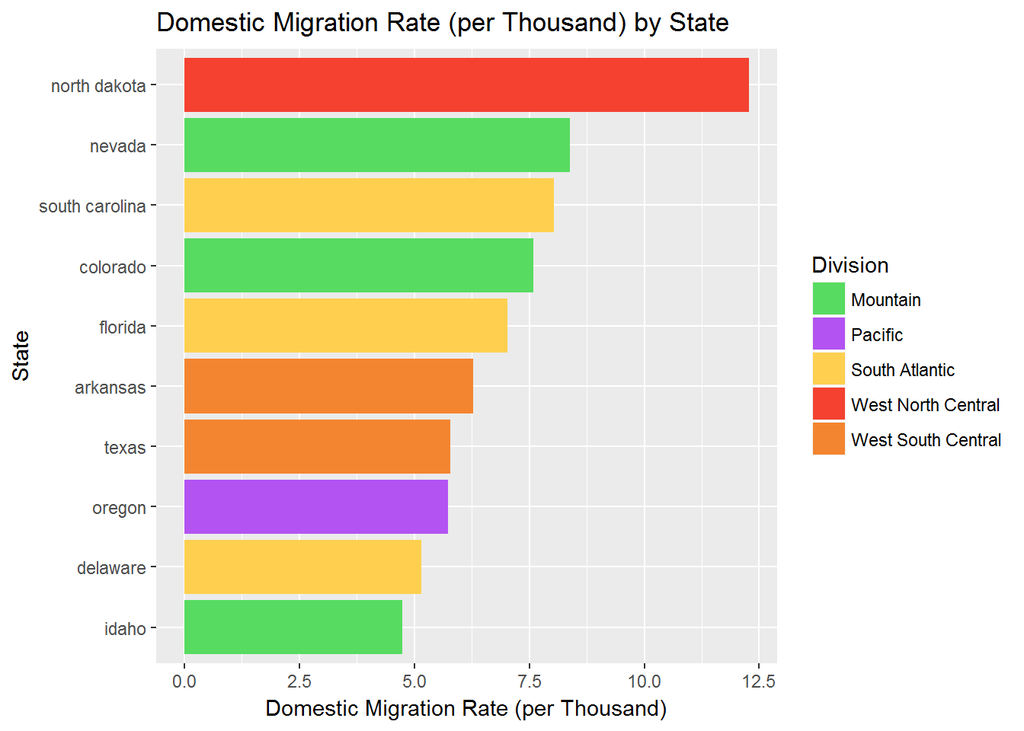

```r
# Graph of states with the 10 highest domestic migration rates
DomMigRateHighBar <- ggplot(DomMigRateHigh, aes(reorder(State, DomMigRate), DomMigRate, fill=Division)) # Creating the basic plot
DomMigRateHighBar<- DomMigRateHighBar + geom_col() + coord_flip() + labs(y="Domestic Migration Rate (per Thousand)", x="State", title="Domestic Migration Rate (per Thousand) by State")  + scale_fill_manual(values=DivColMap)
DomMigRateHighBar
```

- Woah, North Dakota is gaining a lot of people (percentage-wise)! Nevada, South Carolina, Colorado, and Florida are next highest.
- Half of the states in the West South Central division are represented, almost 40% of South Atlantic and Mountain states are also represented.

### 2.4.5 Net Migration (Low)

```r
# Lowest net migration rates by state and division

# Creating table of states with 10 lowest net migration rates
NetMigRateLow <- select(Census2014, State, Division, NetMigRate) %>%
  filter(NetMigRate <= sort(NetMigRate)[10]) %>%
  mutate(NetMigRate = round(NetMigRate, 2))

# Table of states with 10 lowest net migration rates
NetMigRateLow %>%
  arrange(desc(NetMigRate))
```

```
##          State           Division NetMigRate
## 1     michigan East North Central      -0.87
## 2      vermont        New England      -1.32
## 3     new york    Middle Atlantic      -1.78
## 4  mississippi East South Central      -2.38
## 5  connecticut        New England      -2.56
## 6       kansas West North Central      -2.71
## 7      wyoming           Mountain      -3.75
## 8     illinois East North Central      -4.85
## 9   new mexico           Mountain      -5.50
## 10      alaska            Pacific     -10.88
```

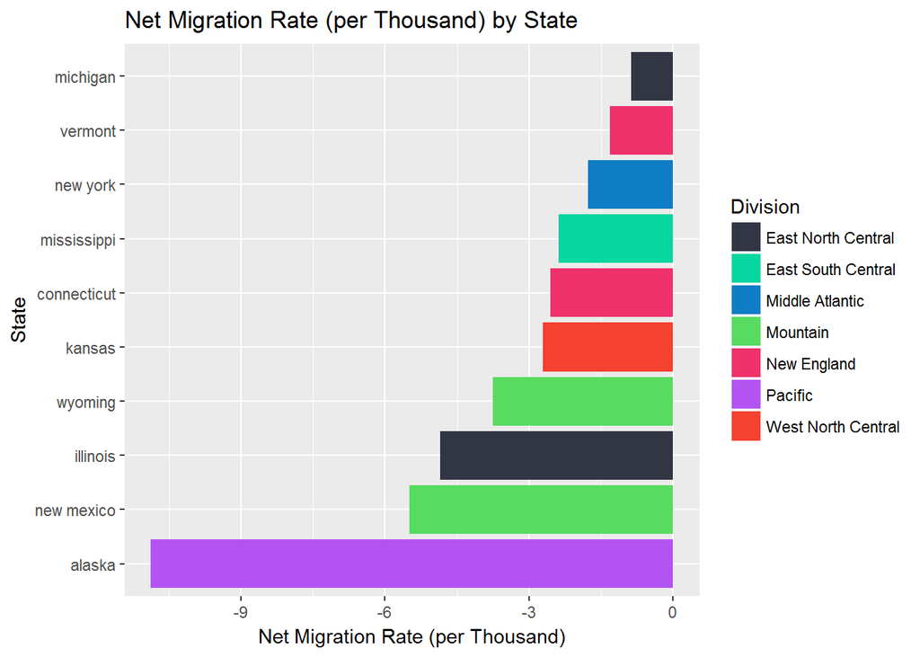

```r
# Graph of states with 10 lowest net migration rates
NetMigRateLowBar <- ggplot(NetMigRateLow, aes(reorder(State, NetMigRate), NetMigRate, fill=Division)) # Creating basic graph
NetMigRateLowBar <- NetMigRateLowBar + geom_col() + coord_flip() + labs(y="Net Migration Rate (per Thousand)", x="State", title="Net Migration Rate (per Thousand) by State")  + scale_fill_manual(values=DivColMap)
NetMigRateLowBar
```

- As this is just the addition of the international and domestic migration rates, it is unsurprising that Alaska is so low.
- A scary note: the bottom 10 states are losing people in terms from migration!

### 2.4.6 Net Migration (High)

```r
# Highest net migration rates by state and division

# Creating table of states with 10 highest net migration rates
NetMigRateHigh <- select(Census2014, State, Division, NetMigRate) %>%
  filter(NetMigRate >= sort(NetMigRate)[41]) %>%
  mutate(NetMigRate = round(NetMigRate, 2))

# Table of states with 10 highest net migration rates
NetMigRateHigh %>%
  arrange(desc(NetMigRate))
```

```
##             State           Division NetMigRate
## 1    north dakota West North Central      14.03
## 2         florida     South Atlantic      12.70
## 3          nevada           Mountain      11.39
## 4        colorado           Mountain       9.60
## 5  south carolina     South Atlantic       9.35
## 6           texas West South Central       8.94
## 7        arkansas West South Central       8.41
## 8        delaware     South Atlantic       7.71
## 9          oregon            Pacific       7.48
## 10     washington            Pacific       7.40
```

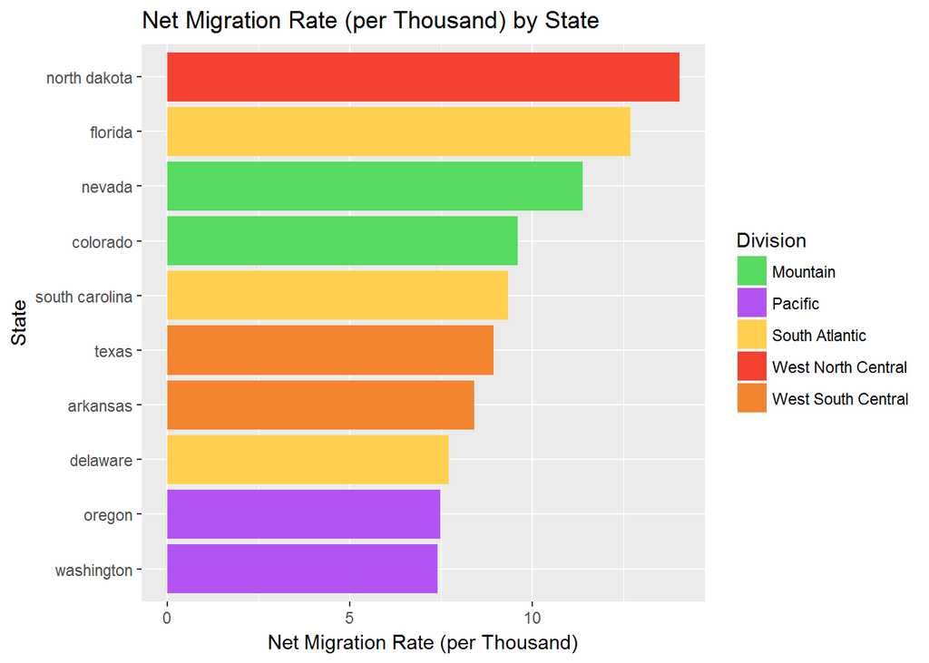

```r
# Graph of states with 10 highest net migration rates
NetMigRateHighBar <- ggplot(NetMigRateHigh, aes(reorder(State, NetMigRate), NetMigRate, fill=Division)) # Creating basic graph
NetMigRateHighBar <- NetMigRateHighBar + geom_col() + coord_flip() + labs(y="Net Migration Rate (per Thousand)", x="State", title="Net Migration Rate (per Thousand) by State")  + scale_fill_manual(values=DivColMap)
NetMigRateHighBar
```

- It is quite apparent that some states are benefitting greatly from net migration, namely North Dakota, Florida, and Nevada.
- Regardless, all top 10 states in this category are gaining many people (in terms of percentage) through migration!
- Almost 40% of the South Atlantic division and 50% of the West South Central division are represented in the top 10.

## 2.5 Migration Maps (Actual Numbers)

Although looking at the percentages of population can be useful, it is important to keep these statistics in context.

I am now going to look at the actual numbers of people instead of rates. I suspect that, although North Dakota and Alaska are outliers in terms of rates, their numbers of migrants will be small compared with larger states’ numbers.

I will start off by creating our variables and mapping them for reference. I suspect that they will look a lot like the 2014 population chart up above.

I found it somewhat surprising that, when looking at the actual numbers, the maps completely change.

```r
# Creating Population Variables
Census2014$IntMig <- round(((Census2014$IntMigRate / 1000) * Census2014$Population), digits=0) # International Migration Numbers
Census2014$DomMig <- round(((Census2014$DomMigRate / 1000) * Census2014$Population), digits=0) # Domestic Migration Numbers
Census2014$NetMig <- round(((Census2014$NetMigRate / 1000) * Census2014$Population), digits=0) # Net Migration Numbers
```

### 2.5.1 Int. Migration

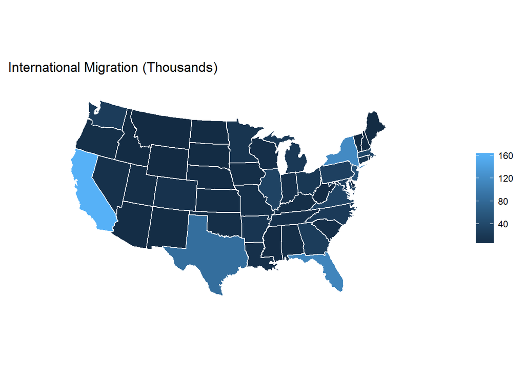

```r
# International Migration Map
IntMig <- USMap # Loading the map
IntMig <- IntMig + geom_map(data=Census2014, map=us, aes(fill=(IntMig/1000), map_id=State), color="#ffffff")
IntMig <- IntMig + theme(panel.border=element_blank(), panel.background=element_blank(), axis.ticks=element_blank(), axis.text=element_blank()) + labs(x=NULL, y=NULL, fill=NULL, title="International Migration (Thousands)") + coord_map("albers", lat0=39, lat1=45) # Making the map beautiful
IntMig
```

### 2.5.2 Dom. Migration

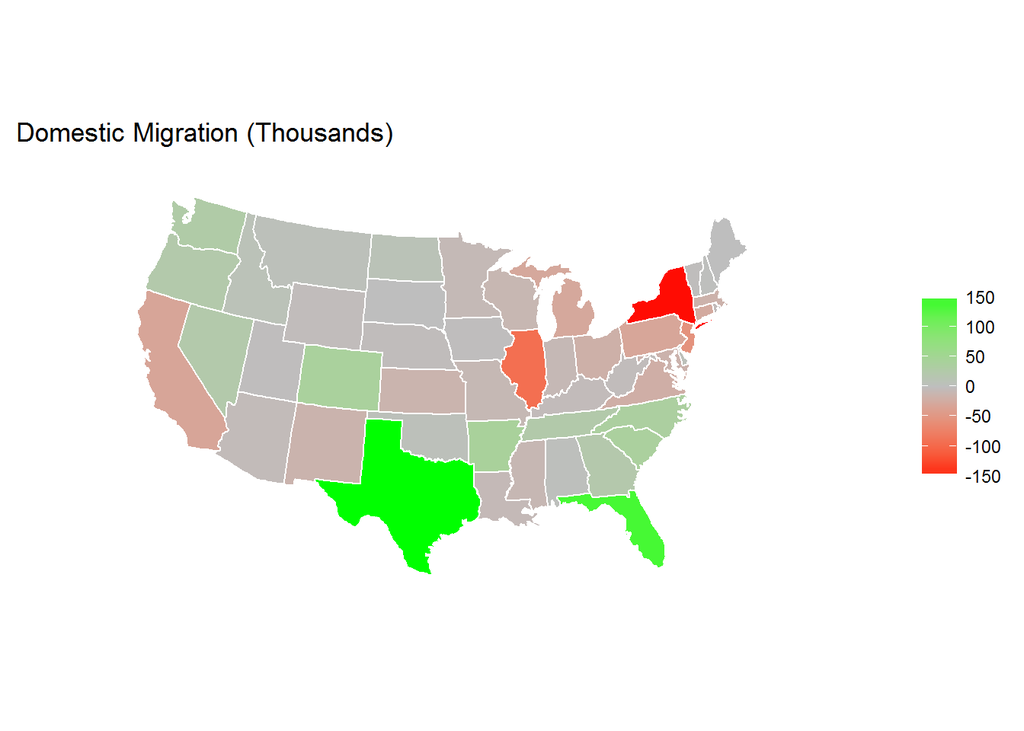

```r
# Domestic Migration Map
DomMig <- USMap # Loading the map
DomMig <- DomMig + geom_map(data=Census2014, map=us, aes(fill=(DomMig/1000), map_id=State), color="#ffffff")
DomMig <- DomMig + theme(panel.border=element_blank(), panel.background=element_blank(), axis.ticks=element_blank(), axis.text=element_blank()) + labs(x=NULL, y=NULL, fill=NULL, title="Domestic Migration (Thousands)") + coord_map("albers", lat0=39, lat1=45) + scale_fill_gradient2(low="red", mid="grey", high="green") # Making the map beautiful
DomMig
```

### 2.5.3 Net Migration

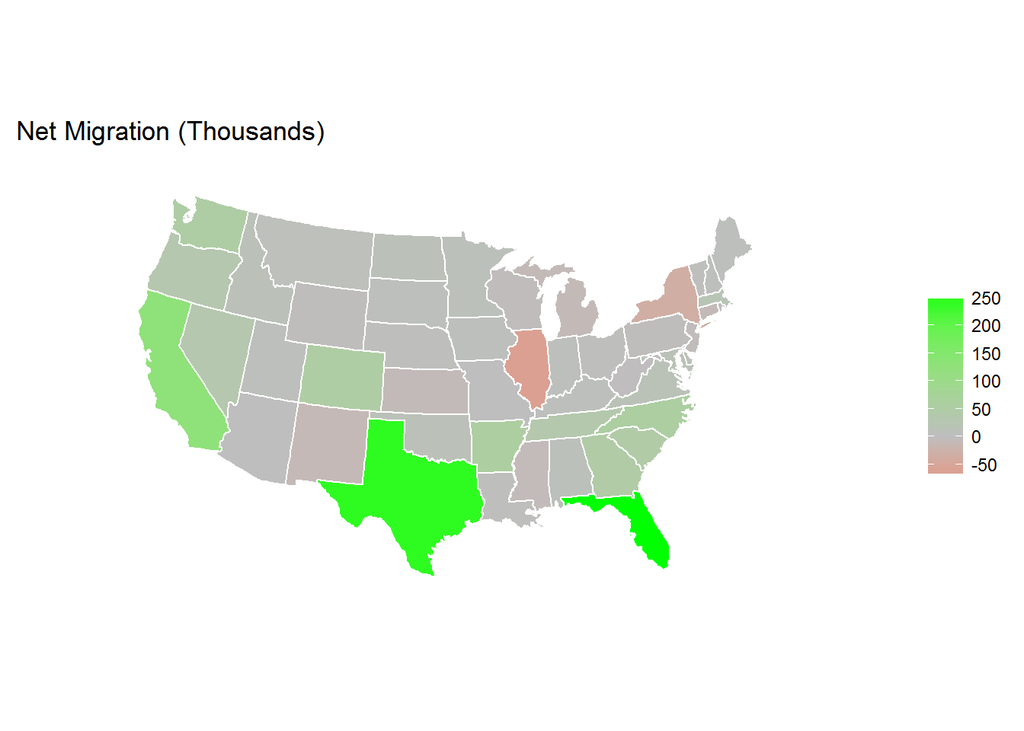

```r
# Net Migration Map
NetMig <- USMap # Loading the map
NetMig <- NetMig + geom_map(data=Census2014, map=us, aes(fill=(NetMig/1000), map_id=State), color="#ffffff")
NetMig <- NetMig + theme(panel.border=element_blank(), panel.background=element_blank(), axis.ticks=element_blank(), axis.text=element_blank()) + labs(x=NULL, y=NULL, fill=NULL, title="Net Migration (Thousands)") + coord_map("albers", lat0=39, lat1=45) + scale_fill_gradient2(low="red", mid="grey", high="green") # Making the map beautiful
NetMig
```

## 2.6 Highest and Lowest Migration Numbers (Actual Numbers)

Before I begin drawing conclusions, I think the correlation of these populations to the total population of a state should be checked to put this into further context.

```r
# Correlations of Populations

# Correlation between population and international migration
print("Population and International Migration: ", quote=FALSE); cor(Census2014$Population, Census2014$IntMig)
## [1] Population and International Migration:
## [1] 0.9282447

# Correlation between population and domestic migration
print("Population and Domestic Migration", quote=FALSE); cor(Census2014$Population, Census2014$DomMig)
## [1] Population and Domestic Migration
## [1] 0.06804198

# Correlation between population and net migration
print("Population and Net Migration", quote=FALSE); cor(Census2014$Population, Census2014$NetMig)
## [1] Population and Net Migration
## [1] 0.6141523
```

- The correlations show:
  - The proportion of international migrants that come to a state (out of all the international migrants) very closely resembles the proportion of that state’s population to the US population as a whole.
  - The migration of people within the US has very little to do with the population of the state they are moving to or from.
  - A state’s population strongly correlates with the net number of migrants.

Here is the top and bottom 10 for each category in tabular format.

### 2.6.1 Int. Migration (Low)

```r
# States with 10 Smallest International Migrant Populations

# Creating table of states with 10 smallest international migrant populations for reference
IntMigLow <- select(Census2014, State, Division, IntMig) %>%
  filter(IntMig <= sort(IntMig)[10]) %>%
  mutate(IntMig = round(IntMig, 1))

# Table of states with 10 smallest international migrant populations
IntMigLow %>%
  arrange(IntMig)
```

```
##            State           Division IntMig
## 1        wyoming           Mountain    485
## 2        vermont        New England    719
## 3        montana           Mountain    769
## 4  west virginia     South Atlantic   1163
## 5   north dakota West North Central   1304
## 6          maine        New England   1378
## 7   south dakota West North Central   1456
## 8          idaho           Mountain   1706
## 9  new hampshire        New England   2029
## 10        alaska            Pacific   2114
```

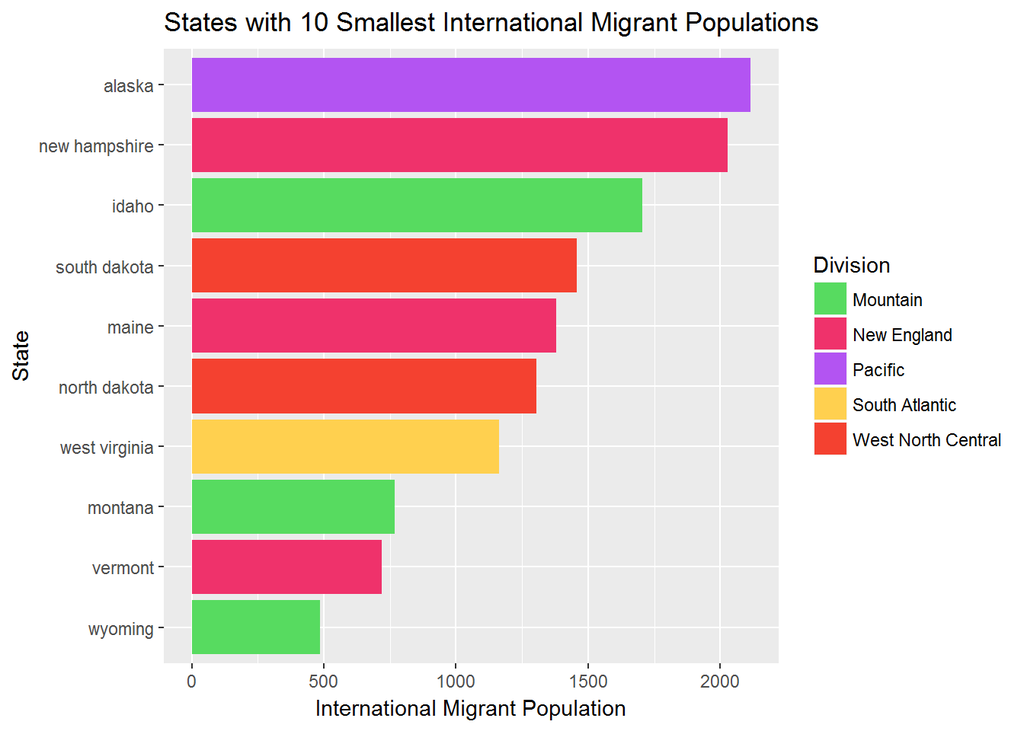

```r
# Graph of states with 10 smallest international migrant populations
IntMigPopLow <- ggplot(IntMigLow, aes(reorder(State, IntMig), IntMig, fill=Division)) # Creating basic graphic
IntMigPopLow <- IntMigPopLow + geom_col() + coord_flip() + labs(y="International Migrant Population", x="State", title="States with 10 Smallest International Migrant Populations") + scale_fill_manual(values=DivColMap)
IntMigPopLow
```

- As I suspected, the positions of the states changed when looking at numbers instead of rates.
- That being said, six out of 10 states in the same category, when listed as rates, remain (Idaho, Montana, Wyoming, Maine, Vermont, West Virginia).
- These 10 states do not have many people moving to them internationally, but they are some of the lowest-populated states in the US.

### 2.6.2 Int. Migration (High)

```r
# States with 10 Largest International Migrant Populations

# Creating table of states with 10 largest international migrant populations
IntMigHigh <- select(Census2014, State, Division, IntMig) %>%
  filter(IntMig >= sort(IntMig)[41]) %>%
  mutate(IntMig = round(IntMig/1000, 1))

# Table of states with 10 largest international migrant populations
IntMigHigh %>%
  arrange(desc(IntMig)) %>%
  rename('IntMig (Thousands)' = IntMig) # Highest 10 international migration populations
```

```
##            State           Division IntMig (Thousands)
## 1     california            Pacific              162.1
## 2       new york    Middle Atlantic              119.0
## 3        florida     South Atlantic              113.1
## 4          texas West South Central               85.4
## 5     new jersey    Middle Atlantic               51.7
## 6  massachusetts        New England               37.4
## 7       virginia     South Atlantic               34.1
## 8       illinois East North Central               32.4
## 9   pennsylvania    Middle Atlantic               29.1
## 10      maryland     South Atlantic               29.0
```

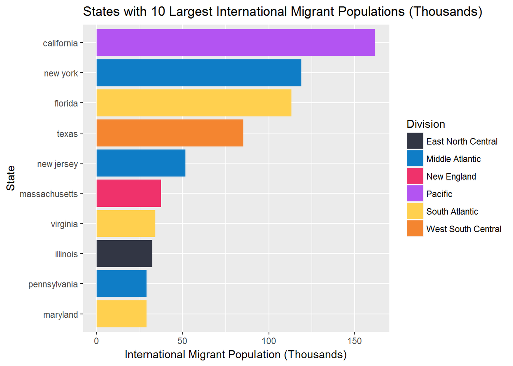

```r
# Graph of states with 10 largest international migrant populations
IntMigPopHigh <- ggplot(IntMigHigh, aes(reorder(State, IntMig), IntMig, fill=Division)) # Creating basic table
IntMigPopHigh <- IntMigPopHigh + geom_col() + coord_flip() + labs(y="International Migrant Population (Thousands)", x="State", title="States with 10 Largest International Migrant Populations (Thousands)") + scale_fill_manual(values=DivColMap)
IntMigPopHigh
```

- Unsurprisingly, the highest rates of immigration to the US take place in the highest-populated states, such as New York, California, Florida, and Texas.
- Although the states with the top 10 international migration rates were on the coast, only 8 of the 10 states in this category lie on the coast (Illinois and Pennsylvania do not, although Pennsylvania is incredibly close).

### 2.6.3 Dom. Migration (Low)

```r
# 10 Smallest Domestic Migrant Populations by State and Division

# Creating table of states with 10 smallest domestic migrant populations for quick reference
DomMigLow <- select(Census2014, State, Division, DomMig) %>%
  filter(DomMig <= sort(DomMig)[10]) %>%
  mutate(DomMig = round(DomMig/1000, 1))

# Table of states with 10 smallest domestic migrant populations
DomMigLow %>%
  arrange(DomMig) %>%
  rename('DomMig (Thousands)' = DomMig)
```

```
##            State           Division DomMig (Thousands)
## 1       new york    Middle Atlantic             -154.1
## 2       illinois East North Central              -94.9
## 3     new jersey    Middle Atlantic              -55.6
## 4     california            Pacific              -32.2
## 5   pennsylvania    Middle Atlantic              -31.5
## 6       michigan East North Central              -28.7
## 7    connecticut        New England              -26.2
## 8       virginia     South Atlantic              -20.5
## 9           ohio East North Central              -18.3
## 10 massachusetts        New England              -16.4
```

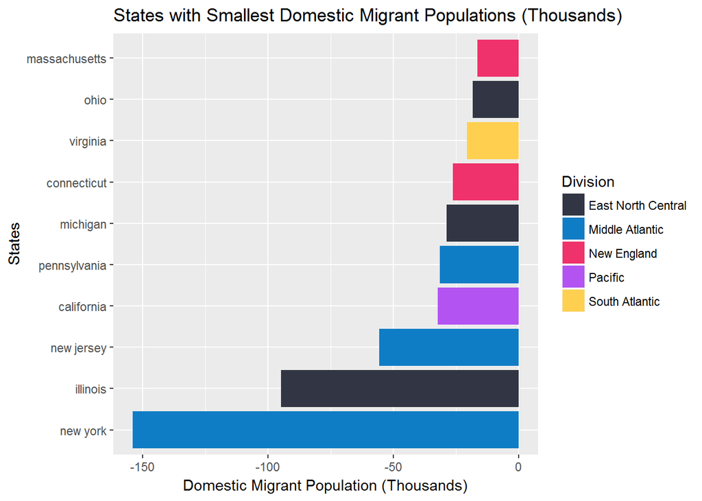

```r
# Graph of states with 10 smallest domestic migrant populations
DomMigPopLow <- ggplot(DomMigLow, aes(reorder(State, DomMig), DomMig, fill=Division)) # Creating basic graphic
DomMigPopLow <- DomMigPopLow + geom_col() + coord_flip() + labs(y="Domestic Migrant Population (Thousands)", x="States", title="States with Smallest Domestic Migrant Populations (Thousands)") + scale_fill_manual(values=DivColMap)
DomMigPopLow
```

- As with the lowest 10 domestic migration rates, these 10 states are losing people (both the rates and actual numbers, of course, are both negative), though New York, Illinois, and New Jersey are losing the most quickly.
- Although Alaska lost over 13 per 1,000 of their population due to domestic migration, their population is so low that they do not even appear on the bottom 10 list in terms of number of people.
- Similarly, Connecticut lost only 6 out of 10,000 less of their population than New York, but New York lost almost 6 times the amount of people due to domestic migration.

### 2.6.4 Dom. Migration (High)

```r
# 10 Largest Domestic Migrant Populations by State and Division

# Creating table of states with 10 largest domestic migrant populations for quick reference
DomMigHigh <- select(Census2014, State, Division, DomMig) %>%
  filter(DomMig >= sort(DomMig)[41]) %>%
  mutate(DomMig = round(DomMig/1000, 1))

# Table of states with 10 largest domestic migrant populations
DomMigHigh %>%
  arrange(desc(DomMig)) %>%
  rename('DomMig (Thousands)' = DomMig)
```

```
##             State           Division DomMig (Thousands)
## 1           texas West South Central              155.8
## 2         florida     South Atlantic              139.6
## 3        arkansas West South Central               42.3
## 4        colorado           Mountain               40.6
## 5  south carolina     South Atlantic               38.9
## 6  north carolina     South Atlantic               36.4
## 7      washington            Pacific               28.2
## 8       tennessee East South Central               24.6
## 9          nevada           Mountain               23.8
## 10         oregon            Pacific               22.8
```

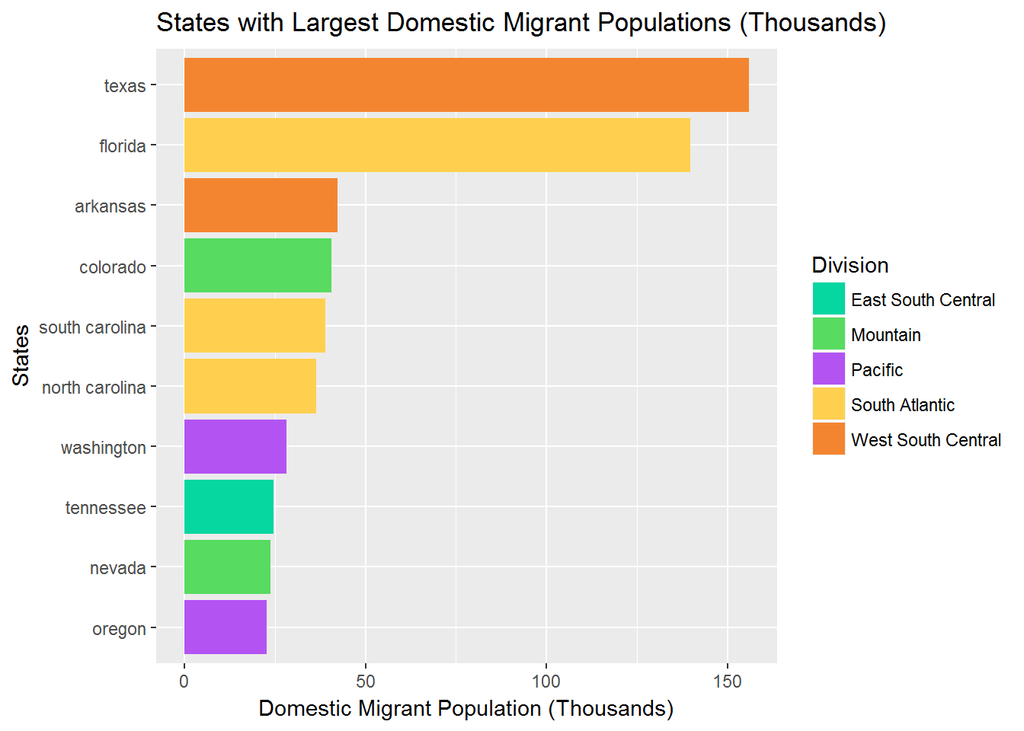

```r
# Graph of states with 10 lowest domestic migrant populations
DomMigPopHigh <- ggplot(DomMigHigh, aes(reorder(State, DomMig), DomMig, fill=Division)) # Creating basic graphic
DomMigPopHigh <- DomMigPopHigh + geom_col() + coord_flip() + labs(y="Domestic Migrant Population (Thousands)", x="States", title="States with Largest Domestic Migrant Populations (Thousands)") + scale_fill_manual(values=DivColMap)
DomMigPopHigh
```

- Texas and Florida gained a lot of people through domestic migration, with third and fourth place coming in with Arkansas and Colorado, respectively.
- North Dakota, South Carolina, and Nevada gained the most people (in terms of percentage of their state populations) through domestic migration, but only South Carolina and Nevada appear on this list, and they did not gain nearly as many people as Texas or Florida.
- No states in the Midwest or north east are on this list, perhaps indicating that people are moving south and west.

### 2.6.5 Net Migration (Low)

```r
# 10 Smallest Net Migrant Populations by State and Division

# Creating table for states with 10 smallest net migration populations for quick reference
NetMigLow <- select(Census2014, State, Division, NetMig) %>%
  filter(NetMig <= sort(NetMig)[10]) %>%
  mutate(NetMig = round(NetMig/1000, 1))

# Table with states with 10 smallest net migration populations
NetMigLow %>%
  arrange(NetMig) %>%
  rename('NetMig (Thousands)' = NetMig)
```

```
##          State           Division NetMig (Thousands)
## 1     illinois East North Central              -62.5
## 2     new york    Middle Atlantic              -35.2
## 3   new mexico           Mountain              -11.5
## 4  connecticut        New England               -9.2
## 5     michigan East North Central               -8.6
## 6       alaska            Pacific               -8.0
## 7       kansas West North Central               -7.9
## 8  mississippi East South Central               -7.1
## 9   new jersey    Middle Atlantic               -3.8
## 10   wisconsin East North Central               -3.4
```

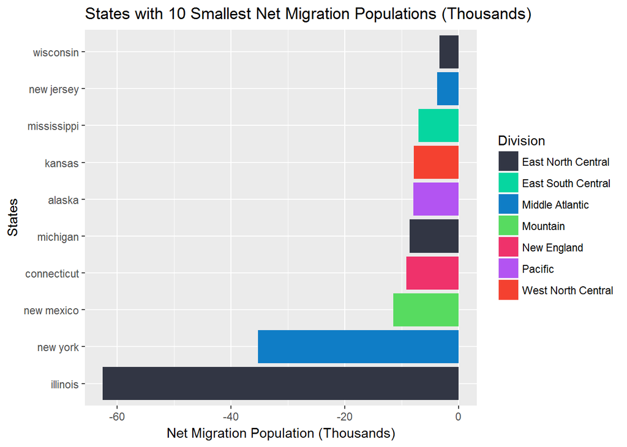

```r
# Graph with states with 10 smallest net migration populations
NetMigPopLow <- ggplot(NetMigLow, aes(reorder(State, NetMig), NetMig, fill=Division)) # Creating basic graphic
NetMigPopLow <- NetMigPopLow + geom_col() + coord_flip() + labs(y="Net Migration Population (Thousands)", x = "States", title="States with 10 Smallest Net Migration Populations (Thousands)") + scale_fill_manual(values = DivColMap) # Making the graphic pretty
NetMigPopLow
```

- Unsurprisingly, Illinois and New York bottom this list due to their domestic migration. However, New Mexico is losing a lot of people as well.
- Although Alaska is losing almost 11 per 1,000 and Illinois almost 5 per 1,000 of their populations through net migration, Alaska is only losing about 1/8 the number of people as Illinois.
- Sixty percent of the East North Central division and 67% of the Middle Atlantic division are represented in this category.

### 2.6.6 Net Migration (High)

```r
# 10 Highest Net Migrant Populations by State and Division

# Creating table for states with 10 largest net migration populations for quick reference
NetMigHigh <- select(Census2014, State, Division, NetMig) %>%
  filter(NetMig >= sort(NetMig)[41]) %>%
  mutate(NetMig = round(NetMig/1000, 1))

# Table with states with 10 largest net migration populations
NetMigHigh %>%
  arrange(desc(NetMig)) %>%
  rename('NetMig (Thousands)' = NetMig)
```

```
##             State           Division NetMig (Thousands)
## 1         florida     South Atlantic              252.7
## 2           texas West South Central              241.1
## 3      california            Pacific              129.8
## 4  north carolina     South Atlantic               57.7
## 5        arkansas West South Central               56.6
## 6      washington            Pacific               52.2
## 7        colorado           Mountain               51.4
## 8         georgia     South Atlantic               47.2
## 9  south carolina     South Atlantic               45.2
## 10      tennessee East South Central               33.8
```

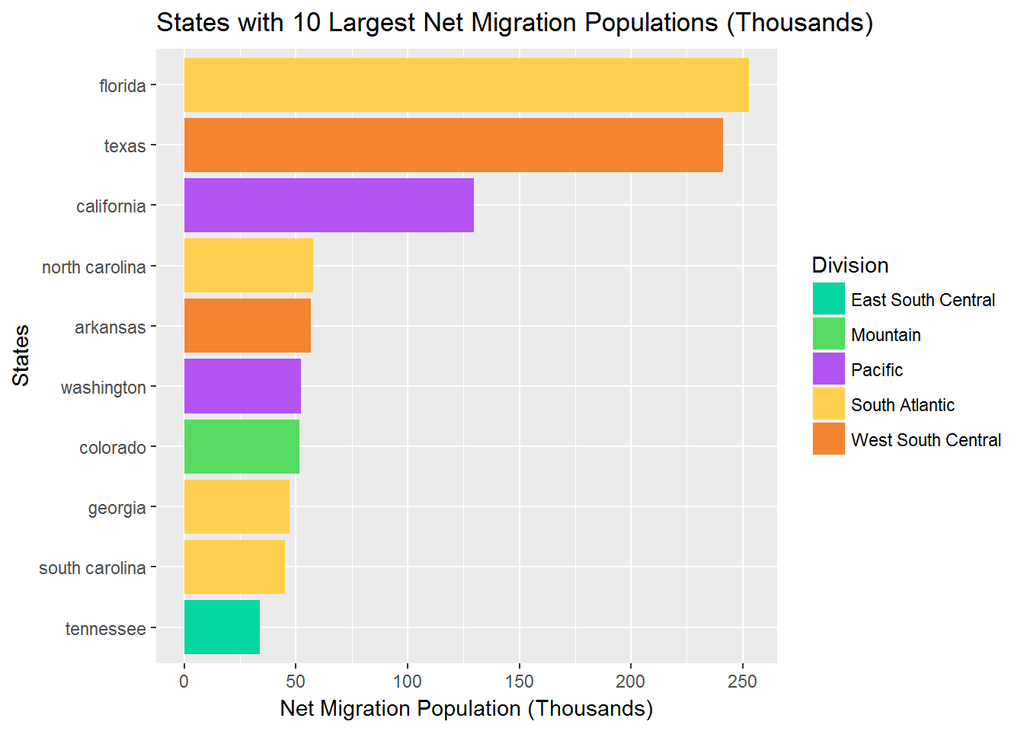

```r
# Graph with states with 10 largest net migration populations
NetMigPopHigh <- ggplot(NetMigHigh, aes(reorder(State, NetMig), NetMig, fill=Division)) # Creating basic graphic
NetMigPopHigh <- NetMigPopHigh + geom_col() + coord_flip() + labs(y="Net Migration Population (Thousands)", x = "States", title="States with 10 Largest Net Migration Populations (Thousands)") + scale_fill_manual(values = DivColMap) # Making the graphic pretty
NetMigPopHigh
```

- Nevada, Florida, and North Dakota all gained over 1% more population through net migration, though only Florida is within the top 10 in terms of number of people.
- Texas, Florida, and California are gaining huge numbers of people through net migration.
- Fifty percent of the South Atlantic and West South Central divisions are represented in this category.

## 2.8 Population Changes by Division

As we saw in the last section, masses of people are moving domestically throughout the US. I will now look at this a bit more closely by observing the numbers and percentages by divisions instead of individual states.

```r
# Creating the variables to use for maps and analysis

# Population by division
Census2014$PopDiv[Census2014$Division == "East North Central"] <- sum(Census2014$Population[Census2014$Division == "East North Central"])
Census2014$PopDiv[Census2014$Division == "East South Central"] <- sum(Census2014$Population[Census2014$Division == "East South Central"])
Census2014$PopDiv[Census2014$Division == "Middle Atlantic"] <- sum(Census2014$Population[Census2014$Division == "Middle Atlantic"])
Census2014$PopDiv[Census2014$Division == "Mountain"] <- sum(Census2014$Population[Census2014$Division == "Mountain"])
Census2014$PopDiv[Census2014$Division == "New England"] <- sum(Census2014$Population[Census2014$Division == "New England"])
Census2014$PopDiv[Census2014$Division == "Pacific"] <- sum(Census2014$Population[Census2014$Division == "Pacific"])
Census2014$PopDiv[Census2014$Division == "South Atlantic"] <- sum(Census2014$Population[Census2014$Division == "South Atlantic"])
Census2014$PopDiv[Census2014$Division == "West North Central"] <- sum(Census2014$Population[Census2014$Division == "West North Central"])
Census2014$PopDiv[Census2014$Division == "West South Central"] <- sum(Census2014$Population[Census2014$Division == "West South Central"])

# Population change (numbers) by division
Census2014$PopChangeDiv[Census2014$Division == "East North Central"] <- sum(Census2014$PopChange2014[Census2014$Division == "East North Central"])
Census2014$PopChangeDiv[Census2014$Division == "East South Central"] <- sum(Census2014$PopChange2014[Census2014$Division == "East South Central"])
Census2014$PopChangeDiv[Census2014$Division == "Middle Atlantic"] <- sum(Census2014$PopChange2014[Census2014$Division == "Middle Atlantic"])
Census2014$PopChangeDiv[Census2014$Division == "Mountain"] <- sum(Census2014$PopChange2014[Census2014$Division == "Mountain"])
Census2014$PopChangeDiv[Census2014$Division == "New England"] <- sum(Census2014$PopChange2014[Census2014$Division == "New England"])
Census2014$PopChangeDiv[Census2014$Division == "Pacific"] <- sum(Census2014$PopChange2014[Census2014$Division == "Pacific"])
Census2014$PopChangeDiv[Census2014$Division == "South Atlantic"] <- sum(Census2014$PopChange2014[Census2014$Division == "South Atlantic"])
Census2014$PopChangeDiv[Census2014$Division == "West North Central"] <- sum(Census2014$PopChange2014[Census2014$Division == "West North Central"])
Census2014$PopChangeDiv[Census2014$Division == "West South Central"] <- sum(Census2014$PopChange2014[Census2014$Division == "West South Central"])

# Population change (rates) by division
Census2014$PopChangeRateDiv <- round(1 + (Census2014$PopChangeDiv/(Census2014$PopDiv-Census2014$PopChangeDiv)), digits=4)
```

### 2.8.1 Population

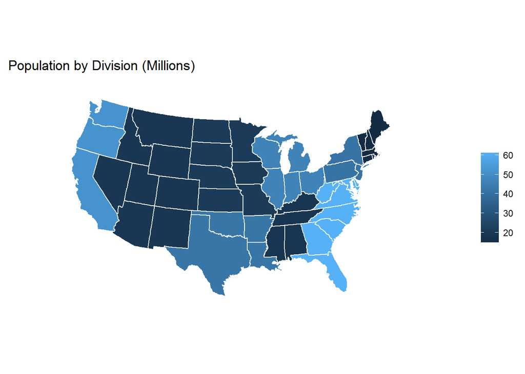

```r
# Populations of Divisions
PopDiv <- USMap # Loading the map
PopDiv <- PopDiv + geom_map(data=Census2014, map=us, aes(fill=(PopDiv/1000000), map_id=State), color="#ffffff")
PopDiv <- PopDiv + theme(panel.border=element_blank(), panel.background=element_blank(), axis.ticks=element_blank(), axis.text=element_blank()) + labs(x=NULL, y=NULL, fill=NULL, title="Population by Division (Millions)") + coord_map("albers", lat0=39, lat1=45) # Making the map more beautiful
PopDiv
```

### 2.8.2 Pop. Change

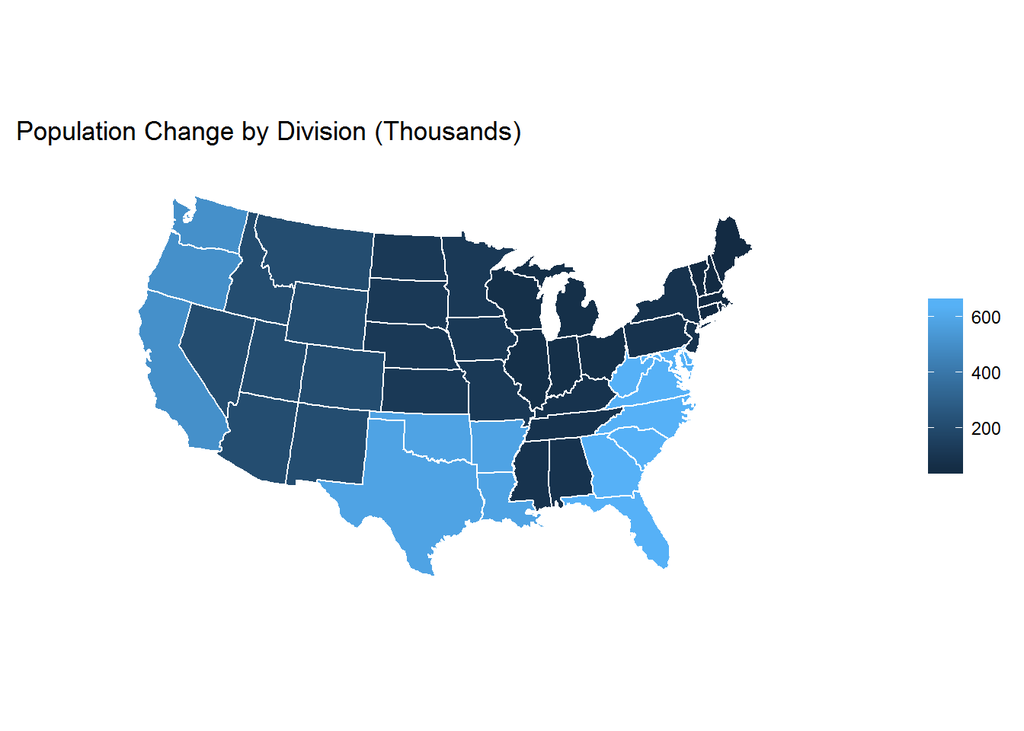

```r
# Population Change (Numbers) of Divisions
PopChangeDiv <- USMap # Loading the map
PopChangeDiv <- PopChangeDiv + geom_map(data=Census2014, map=us, aes(fill=(PopChangeDiv/1000), map_id=State), color="#ffffff")
PopChangeDiv <- PopChangeDiv + theme(panel.border=element_blank(), panel.background=element_blank(), axis.ticks=element_blank(), axis.text=element_blank()) + labs(x=NULL, y=NULL, fill=NULL, title="Population Change by Division (Thousands)") + coord_map("albers", lat0=39, lat1=45)
PopChangeDiv
```

### 2.8.3 Pop. Change Rate

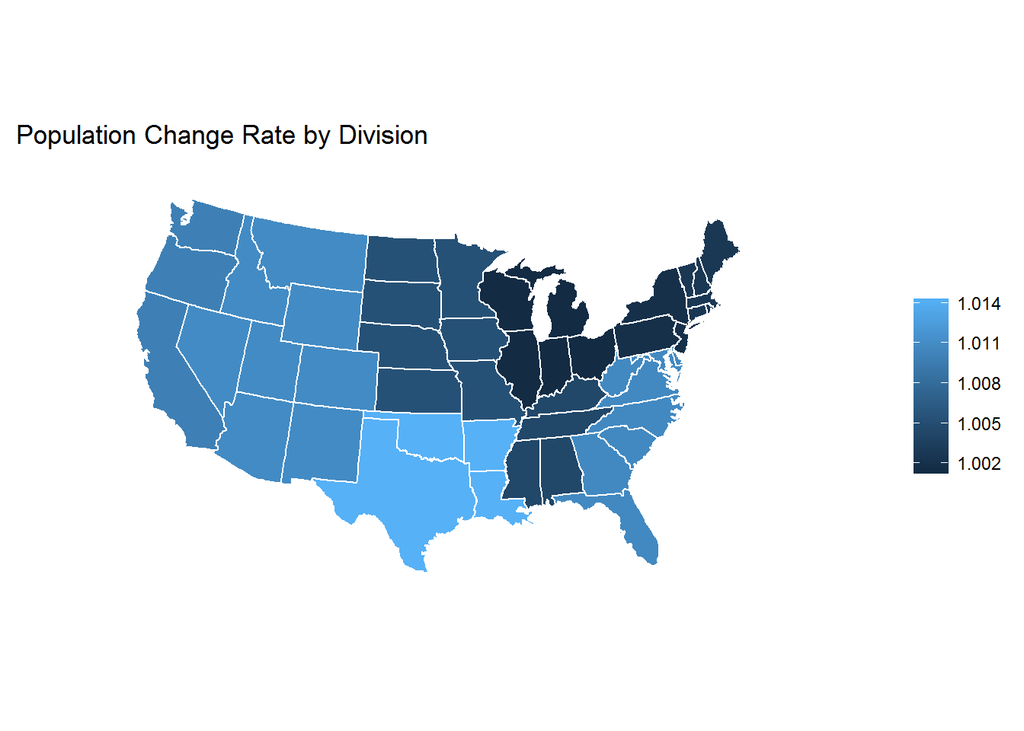

```r
# Population Change (Rates) of Divisions
PopChangeRateDiv <- USMap # Loading the map
PopChangeRateDiv <- PopChangeRateDiv + geom_map(data=Census2014, map=us, aes(fill=PopChangeRateDiv, map_id=State), color="#ffffff")
PopChangeRateDiv <- PopChangeRateDiv + theme(panel.border=element_blank(), panel.background=element_blank(), axis.ticks=element_blank(), axis.text=element_blank()) + labs(x=NULL, y=NULL, fill=NULL, title="Population Change Rate by Division") + coord_map("albers", lat0=39, lat1=45) # Making the map more beautiful
PopChangeRateDiv
```

### 2.8.4 Divisions Map

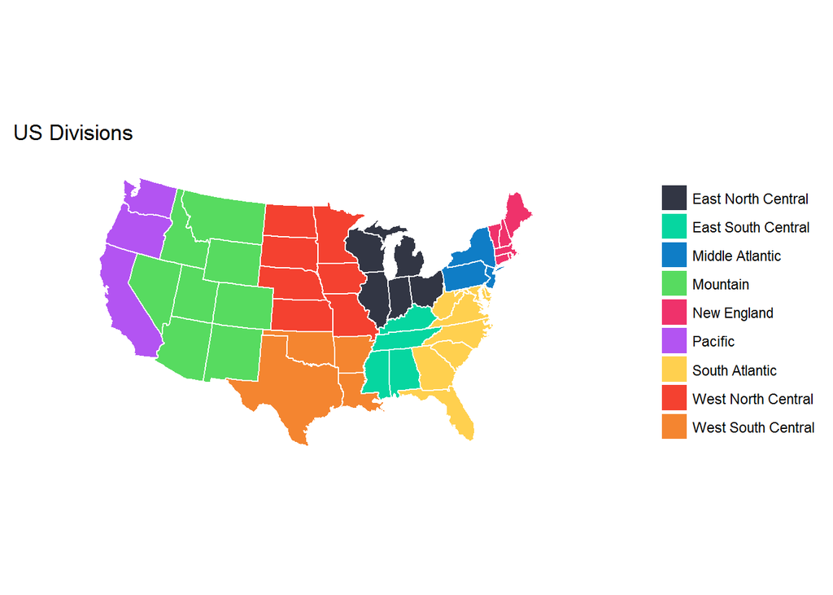

```r
# Here's the division map for reference
GGDivision
```

Here is the information in tabular format for reference.

```r
# Tabling Populations and Changes by Division

group_by(Census2014, Division) %>%
  summarise(PopChangeRateDiv = mean(PopChangeRateDiv), PopChangeDiv = round(mean(PopChangeDiv/1000), 2), PopDiv = round(mean(PopDiv/1000000), 2)) %>%
  rename('Pop. Change Rate' = PopChangeRateDiv, 'Pop. Change (K)' = PopChangeDiv, 'Pop. (MM)' = PopDiv)
```

```
## # A tibble: 9 × 4
##             Division `Pop. Change Rate` `Pop. Change (K)` `Pop. (MM)`
##               <fctr>              <dbl>             <dbl>       <dbl>
## 1 East North Central             1.0014             64.62       46.74
## 2 East South Central             1.0044             83.21       18.81
## 3    Middle Atlantic             1.0020             83.13       41.47
## 4           Mountain             1.0109            209.05       19.43
## 5        New England             1.0028             40.98       14.68
## 6            Pacific             1.0099            511.11       51.99
## 7     South Atlantic             1.0107            651.89       61.86
## 8 West North Central             1.0054            112.61       21.01
## 9 West South Central             1.0143            593.13       42.22
```

Notes on Maps  
* Population: + As we can see from the map and table, the South Atlantic division has the most population at almost 62 million. The Pacific is next, followed by East North Central, West South Central, and Middle Atlantic. + The most populous states are along a coast to an ocean or the great lakes.

- Population Change:
  - Although states in the New England and Middle Atlantic divisions lost many people through domestic migration, every division gained people.
  - The South Atlantic, West South Central, and Pacific divisions gained the most people. These division also grew the fastest (in addition to the Mountain division).
  - As previously discussed, the conclusion that people are moving south and west seems to be supported by looking at these date on a division-level.

# 3 Final Conclusions

- The most populous regions of the US are along the coasts, specifically in Florida, Texas, California, and New York. However, the most populous areas are the South Atlantic, Pacific, and East North Central divisions.
- Utah has a crazy high birth rate while the northeastern states have a crazy low birth rate. The west-midwestern, mountain, and pacific states are increasing their numbers naturally at a high rate.
- Every state gained people through international immigration, though many states lost a high number of people through domestic migration (New York, Illinois, New Jersey), especially the northeastern states.
- Many states also gained a lot of people through migration, whether it be domestic or international. Some example states include Texas, California, and Florida.
- On a larger level, people seem to be moving south and west, with the West South Central, Mountain, South Atlantic, and Pacific divisions growing the most quickly.